# OZNAL projekt 1

Peter Slovák, Pavol Hradský

2024-03-26

## Bc. Peter Slovák, Bc. Pavol Hradský

# Načítanie dát, pred úpravou

```r
data <- read_csv("Life Expectancy Data.csv", col_names = TRUE)
data
```

```
## # A tibble: 2,938 × 22
##    Country      Year Status  `Life expectancy` `Adult Mortality` `infant deaths`
##    <chr>       <dbl> <chr>               <dbl>             <dbl>           <dbl>
##  1 Afghanistan  2015 Develo…              65                 263              62
##  2 Afghanistan  2014 Develo…              59.9               271              64
##  3 Afghanistan  2013 Develo…              59.9               268              66
##  4 Afghanistan  2012 Develo…              59.5               272              69
##  5 Afghanistan  2011 Develo…              59.2               275              71
##  6 Afghanistan  2010 Develo…              58.8               279              74
##  7 Afghanistan  2009 Develo…              58.6               281              77
##  8 Afghanistan  2008 Develo…              58.1               287              80
##  9 Afghanistan  2007 Develo…              57.5               295              82
## 10 Afghanistan  2006 Develo…              57.3               295              84
## # ℹ 2,928 more rows
## # ℹ 16 more variables: Alcohol <dbl>, `percentage expenditure` <dbl>,
## #   `Hepatitis B` <dbl>, Measles <dbl>, BMI <dbl>, `under-five deaths` <dbl>,
## #   Polio <dbl>, `Total expenditure` <dbl>, Diphtheria <dbl>, `HIV/AIDS` <dbl>,
## #   GDP <dbl>, Population <dbl>, `thinness  1-19 years` <dbl>,
## #   `thinness 5-9 years` <dbl>, `Income composition of resources` <dbl>,
## #   Schooling <dbl>
```

# Čo je v našich dátach?

```r
str(data) # struktura dát
```

```
## spc_tbl_ [2,938 × 22] (S3: spec_tbl_df/tbl_df/tbl/data.frame)
##  $ Country                        : chr [1:2938] "Afghanistan" "Afghanistan" "Afghanistan" "Afghanistan" ...
##  $ Year                           : num [1:2938] 2015 2014 2013 2012 2011 ...
##  $ Status                         : chr [1:2938] "Developing" "Developing" "Developing" "Developing" ...
##  $ Life expectancy                : num [1:2938] 65 59.9 59.9 59.5 59.2 58.8 58.6 58.1 57.5 57.3 ...
##  $ Adult Mortality                : num [1:2938] 263 271 268 272 275 279 281 287 295 295 ...
##  $ infant deaths                  : num [1:2938] 62 64 66 69 71 74 77 80 82 84 ...
##  $ Alcohol                        : num [1:2938] 0.01 0.01 0.01 0.01 0.01 0.01 0.01 0.03 0.02 0.03 ...
##  $ percentage expenditure         : num [1:2938] 71.3 73.5 73.2 78.2 7.1 ...
##  $ Hepatitis B                    : num [1:2938] 65 62 64 67 68 66 63 64 63 64 ...
##  $ Measles                        : num [1:2938] 1154 492 430 2787 3013 ...
##  $ BMI                            : num [1:2938] 19.1 18.6 18.1 17.6 17.2 16.7 16.2 15.7 15.2 14.7 ...
##  $ under-five deaths              : num [1:2938] 83 86 89 93 97 102 106 110 113 116 ...
##  $ Polio                          : num [1:2938] 6 58 62 67 68 66 63 64 63 58 ...
##  $ Total expenditure              : num [1:2938] 8.16 8.18 8.13 8.52 7.87 9.2 9.42 8.33 6.73 7.43 ...
##  $ Diphtheria                     : num [1:2938] 65 62 64 67 68 66 63 64 63 58 ...
##  $ HIV/AIDS                       : num [1:2938] 0.1 0.1 0.1 0.1 0.1 0.1 0.1 0.1 0.1 0.1 ...
##  $ GDP                            : num [1:2938] 584.3 612.7 631.7 670 63.5 ...
##  $ Population                     : num [1:2938] 33736494 327582 31731688 3696958 2978599 ...
##  $ thinness  1-19 years           : num [1:2938] 17.2 17.5 17.7 17.9 18.2 18.4 18.6 18.8 19 19.2 ...
##  $ thinness 5-9 years             : num [1:2938] 17.3 17.5 17.7 18 18.2 18.4 18.7 18.9 19.1 19.3 ...
##  $ Income composition of resources: num [1:2938] 0.479 0.476 0.47 0.463 0.454 0.448 0.434 0.433 0.415 0.405 ...
##  $ Schooling                      : num [1:2938] 10.1 10 9.9 9.8 9.5 9.2 8.9 8.7 8.4 8.1 ...
##  - attr(*, "spec")=
##   .. cols(
##   ..   Country = col_character(),
##   ..   Year = col_double(),
##   ..   Status = col_character(),
##   ..   `Life expectancy` = col_double(),
##   ..   `Adult Mortality` = col_double(),
##   ..   `infant deaths` = col_double(),
##   ..   Alcohol = col_double(),
##   ..   `percentage expenditure` = col_double(),
##   ..   `Hepatitis B` = col_double(),
##   ..   Measles = col_double(),
##   ..   BMI = col_double(),
##   ..   `under-five deaths` = col_double(),
##   ..   Polio = col_double(),
##   ..   `Total expenditure` = col_double(),
##   ..   Diphtheria = col_double(),
##   ..   `HIV/AIDS` = col_double(),
##   ..   GDP = col_double(),
##   ..   Population = col_double(),
##   ..   `thinness  1-19 years` = col_double(),
##   ..   `thinness 5-9 years` = col_double(),
##   ..   `Income composition of resources` = col_double(),
##   ..   Schooling = col_double()
##   .. )
##  - attr(*, "problems")=<externalptr>
```

```r
head(data)
```

```
## # A tibble: 6 × 22
##   Country      Year Status   `Life expectancy` `Adult Mortality` `infant deaths`
##   <chr>       <dbl> <chr>                <dbl>             <dbl>           <dbl>
## 1 Afghanistan  2015 Develop…              65                 263              62
## 2 Afghanistan  2014 Develop…              59.9               271              64
## 3 Afghanistan  2013 Develop…              59.9               268              66
## 4 Afghanistan  2012 Develop…              59.5               272              69
## 5 Afghanistan  2011 Develop…              59.2               275              71
## 6 Afghanistan  2010 Develop…              58.8               279              74
## # ℹ 16 more variables: Alcohol <dbl>, `percentage expenditure` <dbl>,
## #   `Hepatitis B` <dbl>, Measles <dbl>, BMI <dbl>, `under-five deaths` <dbl>,
## #   Polio <dbl>, `Total expenditure` <dbl>, Diphtheria <dbl>, `HIV/AIDS` <dbl>,
## #   GDP <dbl>, Population <dbl>, `thinness  1-19 years` <dbl>,
## #   `thinness 5-9 years` <dbl>, `Income composition of resources` <dbl>,
## #   Schooling <dbl>
```

```r
dim(data) # rozmery dát
```

```
## [1] 2938   22
```

```r
sapply(data, class) # vela numerickych dat, vypisane podrobne
```

```
##                         Country                            Year
##                     "character"                       "numeric"
##                          Status                 Life expectancy
##                     "character"                       "numeric"
##                 Adult Mortality                   infant deaths
##                       "numeric"                       "numeric"
##                         Alcohol          percentage expenditure
##                       "numeric"                       "numeric"
##                     Hepatitis B                         Measles
##                       "numeric"                       "numeric"
##                             BMI               under-five deaths
##                       "numeric"                       "numeric"
##                           Polio               Total expenditure
##                       "numeric"                       "numeric"
##                      Diphtheria                        HIV/AIDS
##                       "numeric"                       "numeric"
##                             GDP                      Population
##                       "numeric"                       "numeric"
##            thinness  1-19 years              thinness 5-9 years
##                       "numeric"                       "numeric"
## Income composition of resources                       Schooling
##                       "numeric"                       "numeric"
```

Dáta obsahujú **22 stĺpcov** a **2938 záznamov** o kvalite a dĺžke života v **193 krajinách** naprieč rokmi **2000-2015**.

```r
table(sapply(data, class))
```

```
##
## character   numeric
##         2        20
```

**20 stĺpcov** je **numerických** a **2 kategorické**. Niektoré stĺpce obsahujú aj **NA** hodnoty.

**Kategorické stĺpce:** Country, Status.

**Numerické stĺpce:** Year, Life expectancy, Adult Mortality, infant deaths, Alcohol, percentage expenditure, Hepatitis B, Measles, BMI, under-five deaths, Polio, Total expenditure, Diphtheria, HIV/AIDS, GDP, Population, thinness 1-19 years, thinness 5-9 years, Income composition of resources, Schooling.

```r
# Ideme zistit, ci sa v stlpci Life expectancy nachadzaju nejake chybajuce hodnoty, alebo prazdne hodnoty pretoze to je stlpec, ktory budeme predikovat a je pre nas dolezity

# kontrola pre chybajuce hodnoty v stlpci Life expectancy. Zistili sme, ze v stlpci Life expectancy sa nachadza 10 chybajucich hodnot - NA
sum(is.na(data$`Life expectancy`))
```

```
## [1] 10
```

```r
# kontrola pre prazdne hodnoty
sum(str_detect(data$`Life expectancy`, "^\\s*$"))
```

```
## [1] NA
```

Vidíme, že v stĺpci Life expectancy sa nachádza len **10** prázdnych hodnôt - **NA** a **žiaden prázdny reťazec**. Tento stĺpec bude pre nás dôležitý pri lineárnej regresii, kde budeme predikovať práve dĺžku života na základe iných parametrov. Rozhodli sme sa **dropnúť riadky s chýbajúcimi hodnotami v tomto stĺpci**.

# Čistenie datasetu

- odstránenie riadkov s chýbajúcimi hodnotami v stĺpci Life expectancy

```r
data <- data %>% drop_na(`Life expectancy`)
missing_values_life_axpextancy <- sum(is.na(data$`Life expectancy`))
missing_values_life_axpextancy
```

```
## [1] 0
```

```r
dim(data)
```

```
## [1] 2928   22
```

## Úprava datasetu o stĺpec Continent, pre možné budúce použitie.

```r
install.packages("countrycode", repos="https://cloud.r-project.org/")
library(countrycode)
data$Continent <- countrycode(data$Country, "country.name", "continent")
data
```

```
## # A tibble: 2,928 × 23
##    Country      Year Status  `Life expectancy` `Adult Mortality` `infant deaths`
##    <chr>       <dbl> <chr>               <dbl>             <dbl>           <dbl>
##  1 Afghanistan  2015 Develo…              65                 263              62
##  2 Afghanistan  2014 Develo…              59.9               271              64
##  3 Afghanistan  2013 Develo…              59.9               268              66
##  4 Afghanistan  2012 Develo…              59.5               272              69
##  5 Afghanistan  2011 Develo…              59.2               275              71
##  6 Afghanistan  2010 Develo…              58.8               279              74
##  7 Afghanistan  2009 Develo…              58.6               281              77
##  8 Afghanistan  2008 Develo…              58.1               287              80
##  9 Afghanistan  2007 Develo…              57.5               295              82
## 10 Afghanistan  2006 Develo…              57.3               295              84
## # ℹ 2,918 more rows
## # ℹ 17 more variables: Alcohol <dbl>, `percentage expenditure` <dbl>,
## #   `Hepatitis B` <dbl>, Measles <dbl>, BMI <dbl>, `under-five deaths` <dbl>,
## #   Polio <dbl>, `Total expenditure` <dbl>, Diphtheria <dbl>, `HIV/AIDS` <dbl>,
## #   GDP <dbl>, Population <dbl>, `thinness  1-19 years` <dbl>,
## #   `thinness 5-9 years` <dbl>, `Income composition of resources` <dbl>,
## #   Schooling <dbl>, Continent <chr>
```

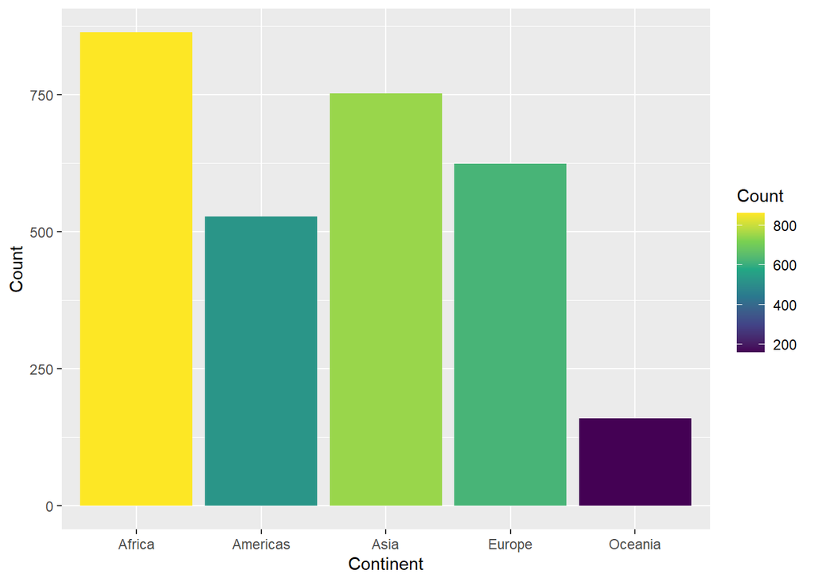

```r
# počet krajín v jednotlivých kontinentoch
data %>%
  count(Continent) %>%
  rename(Count = n) %>%
  ggplot(aes(x=Continent, y=Count)) +
  geom_histogram(stat="identity", aes(fill=Count)) +
  scale_fill_viridis_c()
```

```r
dim(data)
```

```
## [1] 2928   23
```

Vidíme, že najviac záznamov máme z **Afriky, Ázie a Európy**.

# Histogramy

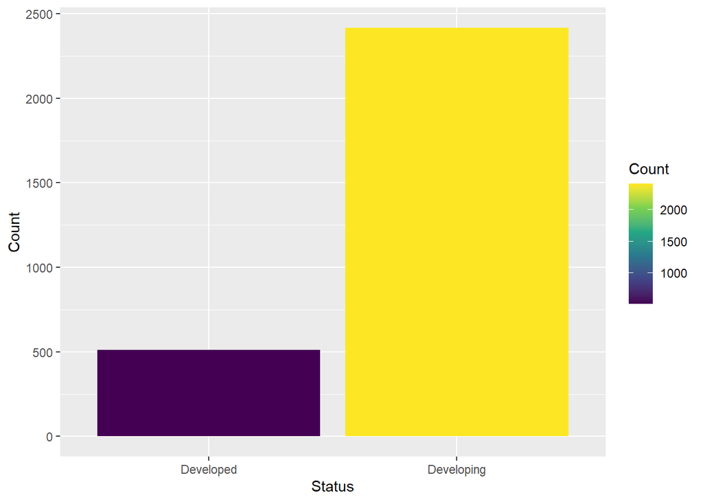

```r
# Histogram rozvojových a rozvinutých krajín
data %>%
  count(Status) %>%
  rename(Count = n) %>%
  ggplot(aes(x=Status, y=Count)) +
  geom_histogram(stat="identity", aes(fill=Count)) +
  scale_fill_viridis_c()
```

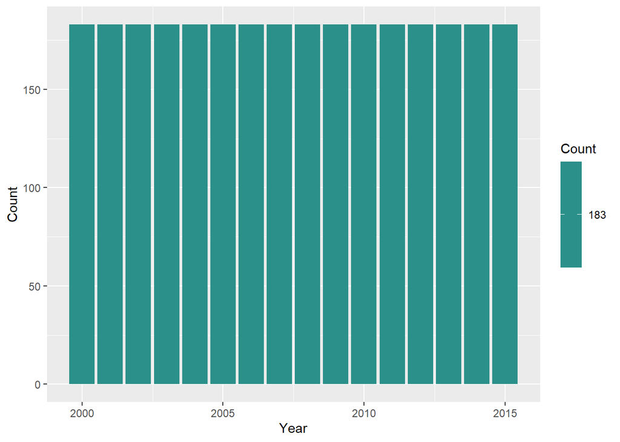

```r
# Histogram rokov, kedy boli robené merania
data %>%
  count(Year) %>%
  rename(Count = n) %>%
  ggplot(aes(x=Year, y=Count)) +
  geom_histogram(stat="identity", aes(fill=Count)) +
  scale_fill_viridis_c()
```

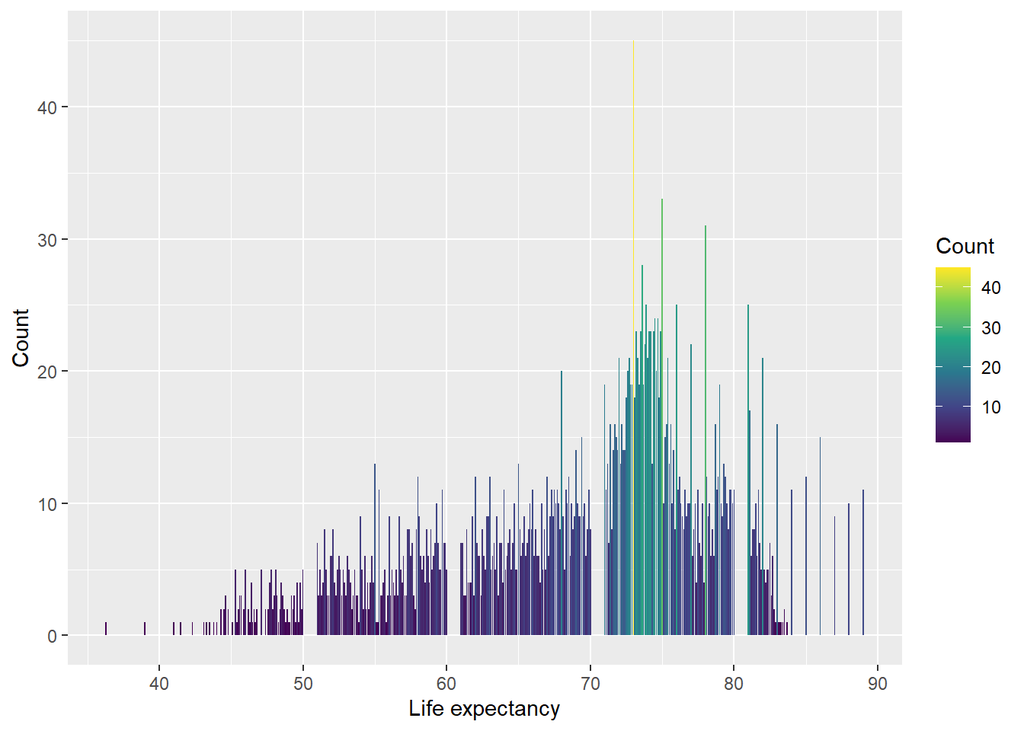

```r
# Histogram dĺžky života
data %>%
  count(`Life expectancy`) %>%
  rename(Count = n) %>%
  ggplot(aes(x=`Life expectancy`, y=Count)) +
  geom_histogram(stat="identity", aes(fill=Count)) +
  scale_fill_viridis_c()
```

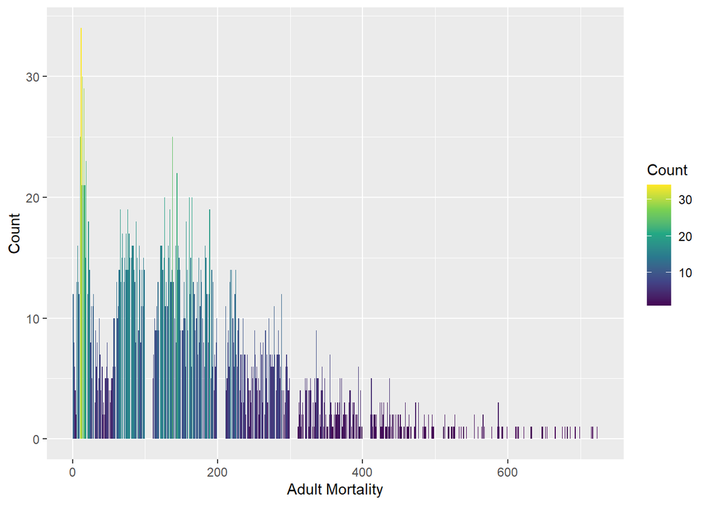

```r
# Histogram adult mortality
data %>%
  count(`Adult Mortality`) %>%
  rename(Count = n) %>%
  ggplot(aes(x=`Adult Mortality`, y=Count)) +
  geom_histogram(stat="identity", aes(fill=Count)) +
  scale_fill_viridis_c()
```

Pri zobrazení histogramov vidíme, že v datasete je **omnoho viac záznamov s rozvojových krajín ako z rozvinutých**. **Roky**, v ktorých boli robené merania, sú zastúpené **rovnomerne**. Pred odstránením predchádzajúcich 10 riadkov pre chýbajúce záznamy v Life expectancy sme mali v jeden rok viac záznamov. Ďalej vidíme rozdelenie dĺžky života a adult mortality.

# Zvyšné chýbajúce hodnoty

```
##                         Country                            Year
##                               0                               0
##                          Status                 Life expectancy
##                               0                               0
##                 Adult Mortality                   infant deaths
##                               0                               0
##                         Alcohol          percentage expenditure
##                             193                               0
##                     Hepatitis B                         Measles
##                             553                               0
##                             BMI               under-five deaths
##                              32                               0
##                           Polio               Total expenditure
##                              19                             226
##                      Diphtheria                        HIV/AIDS
##                              19                               0
##                             GDP                      Population
##                             443                             644
##            thinness  1-19 years              thinness 5-9 years
##                              32                              32
## Income composition of resources                       Schooling
##                             160                             160
##                       Continent
##                               0
```

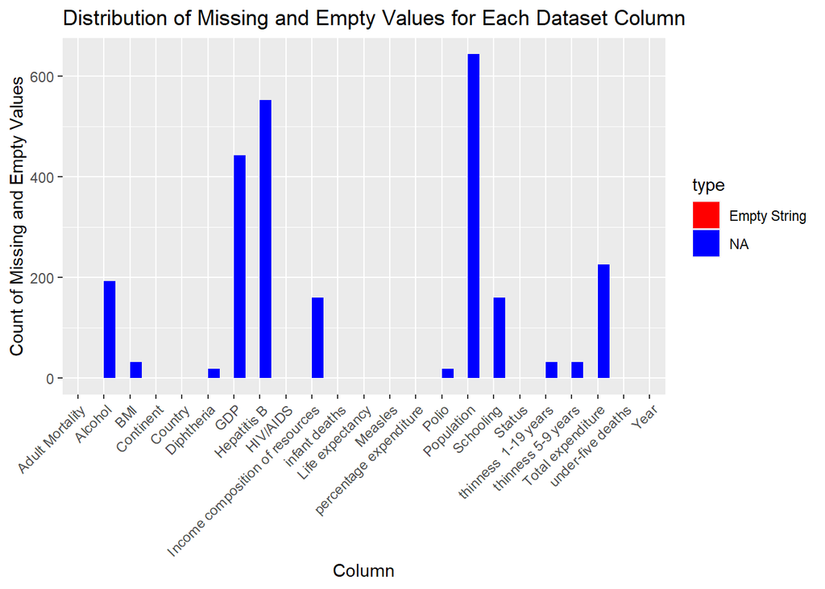

Kontrolovali sme aj ostatné chýbajúce hodnoty. Vidíme, že pomerne dosť sa ich nachádza aj v stĺpcoch **Population** a **hepatits B** alebo **GDB**. V ostaných je len menej, alebo žiadne.

## Pairplot

- identifikácia vzťahov a vzorov medzi premennými

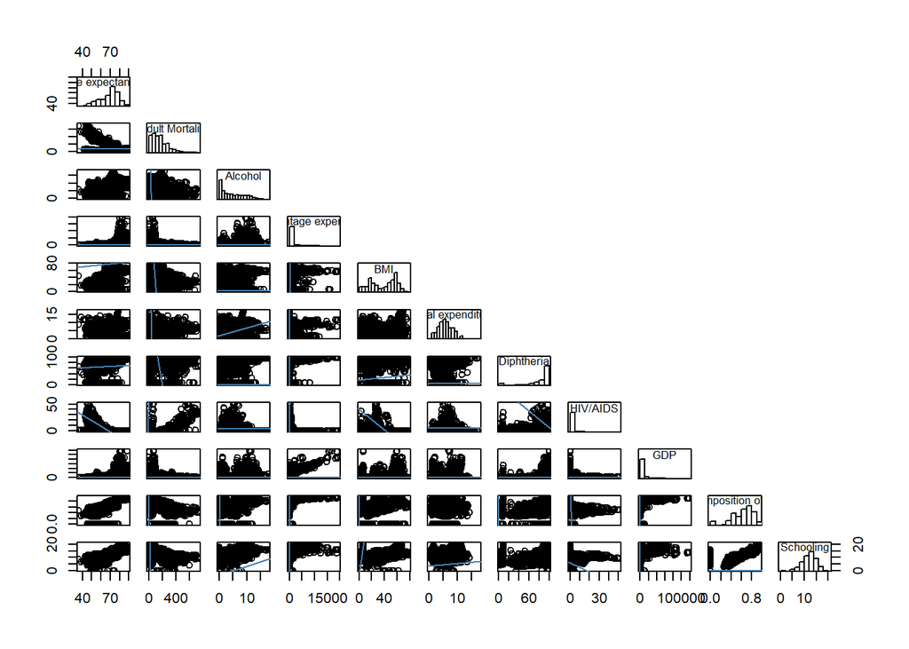

```r
#-----Helper functions----- z cvika, labov prebrate
panel.cor <- function(x,y, digits=2, prefix="", cex.cor){
  usr <- par("usr")
  on.exit(par(usr))
  par(usr = c(0,1,0,1))
  r <- abs(cor(x,y,use="complete.obs"))
  txt <- format(c(r,0.123456789), digits = digits)[1]
  txt <- paste0(prefix, txt,sep="")
  if(missing(cex.cor)) cex.cor <- 0.8/strwidth(txt)
  text(0.5, 0.5, txt, cex = cex.cor * (1 + r) / 2)
}

panel.hist <- function(x, ...){
  usr <- par("usr")
  on.exit(par(usr))
  par(usr = c(usr[1:2],0,1.5))
  h <- hist(x, plot = FALSE)
  breaks <- h$breaks
  nB <- length(breaks)
  y <- h$counts
  y <- y/max(y)
  rect(breaks[-nB], 0, breaks[-1], y, col="white",...)
}

panel.lm <- function(x, y, col = par("col"), bg = NA, pch = par("pch"),
                     cex = 1, col.smooth = "blue", ...) {
  points(x, y, pch = pch, col = col, bg = bg, cex = cex)
  abline(stats::lm(x ~ y), col = "steelblue", ...)
}
pairs(~ `Life expectancy` + `Adult Mortality` + Alcohol  +
        `percentage expenditure` + BMI +
        `Total expenditure` + Diphtheria + `HIV/AIDS` + GDP +
        `Income composition of resources` +
        Schooling,
      data = data,
      upper.panel= NULL,
      diag.panel = panel.hist,
      lower.panel = panel.lm)
```

## Korelačná tabuľka

```r
options(repos = c(CRAN = "https://cran.rstudio.com"))
install.packages("corrplot")
library(corrplot)
# plot with removed na values

cor(data %>% select(`Life expectancy`, `Adult Mortality`, Alcohol,
                    `percentage expenditure`, BMI, `Total expenditure`,
                    Diphtheria, `HIV/AIDS`, GDP, `Income composition of resources`,
                    Schooling), method = "pearson", use = "pairwise.complete.obs")
```

```
##                                 Life expectancy Adult Mortality     Alcohol
## Life expectancy                       1.0000000      -0.6963593  0.40487676
## Adult Mortality                      -0.6963593       1.0000000 -0.19584820
## Alcohol                               0.4048768      -0.1958482  1.00000000
## percentage expenditure                0.3818635      -0.2428595  0.34111199
## BMI                                   0.5676935      -0.3870168  0.33825313
## Total expenditure                     0.2180864      -0.1152807  0.30290165
## Diphtheria                            0.4794949      -0.2751314  0.22237847
## HIV/AIDS                             -0.5565563       0.5238205 -0.04991809
## GDP                                   0.4614552      -0.2960493  0.35440641
## Income composition of resources       0.7247760      -0.4576256  0.45025449
## Schooling                             0.7519755      -0.4546119  0.54800135
##                                 percentage expenditure        BMI
## Life expectancy                             0.38186350  0.5676935
## Adult Mortality                            -0.24285953 -0.3870168
## Alcohol                                     0.34111199  0.3382531
## percentage expenditure                      1.00000000  0.2311297
## BMI                                         0.23112966  1.0000000
## Total expenditure                           0.17624496  0.2387647
## Diphtheria                                  0.14402240  0.2860775
## HIV/AIDS                                   -0.09822981 -0.2437353
## GDP                                         0.89937035  0.3044415
## Income composition of resources             0.38224394  0.5092990
## Schooling                                   0.39146643  0.5583625
##                                 Total expenditure Diphtheria      HIV/AIDS
## Life expectancy                      0.2180863737  0.4794949 -0.5565562534
## Adult Mortality                     -0.1152806886 -0.2751314  0.5238205079
## Alcohol                              0.3029016467  0.2223785 -0.0499180939
## percentage expenditure               0.1762449629  0.1440224 -0.0982298117
## BMI                                  0.2387646604  0.2860775 -0.2437352643
## Total expenditure                    1.0000000000  0.1595923 -0.0003404364
## Diphtheria                           0.1595923136  1.0000000 -0.1652079828
## HIV/AIDS                            -0.0003404364 -0.1652080  1.0000000000
## GDP                                  0.1408947755  0.2010258 -0.1367819585
## Income composition of resources      0.1663752216  0.4012223 -0.2493795171
## Schooling                            0.2625108283  0.4239773 -0.2222141898
##                                        GDP Income composition of resources
## Life expectancy                  0.4614552                       0.7247760
## Adult Mortality                 -0.2960493                      -0.4576256
## Alcohol                          0.3544064                       0.4502545
## percentage expenditure           0.8993703                       0.3822439
## BMI                              0.3044415                       0.5092990
## Total expenditure                0.1408948                       0.1663752
## Diphtheria                       0.2010258                       0.4012223
## HIV/AIDS                        -0.1367820                      -0.2493795
## GDP                              1.0000000                       0.4606268
## Income composition of resources  0.4606268                       1.0000000
## Schooling                        0.4499196                       0.8000463
##                                  Schooling
## Life expectancy                  0.7519755
## Adult Mortality                 -0.4546119
## Alcohol                          0.5480014
## percentage expenditure           0.3914664
## BMI                              0.5583625
## Total expenditure                0.2625108
## Diphtheria                       0.4239773
## HIV/AIDS                        -0.2222142
## GDP                              0.4499196
## Income composition of resources  0.8000463
## Schooling                        1.0000000
```

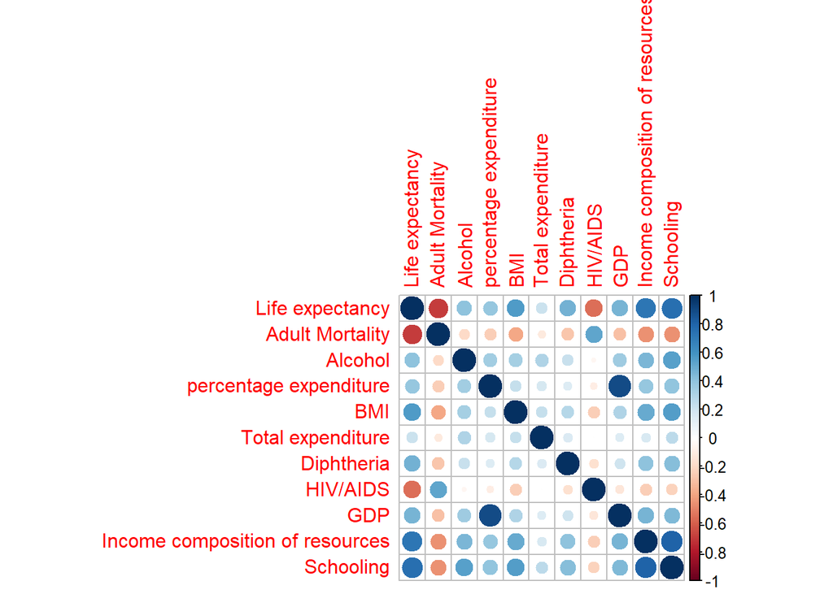

```r
corrplot(cor(data %>% select(`Life expectancy`, `Adult Mortality`, Alcohol,
                    `percentage expenditure`, BMI, `Total expenditure`,
                    Diphtheria, `HIV/AIDS`, GDP, `Income composition of resources`,
                    Schooling), method = "pearson", use = "pairwise.complete.obs"))
```

Vybrali sme len stĺpce, ktoré najviac korelujú so stĺpcom **Life expectancy**, ktorý sa budeme snažiť **predikovať**.

# One hot encode status pre klasifikáciu

```r
data %<>%
  mutate(status_oh = if_else(Status=='Developed', 1, 0)) %>%
  relocate(status_oh)
```

# Rozdelenie dát na trénovacie a testovacie

```r
# train test split
set.seed(123)
train_index <- sample(1:nrow(data), 0.8*nrow(data)) # 80% train, 20% test
train_data <- data[train_index,]
test_data <- data[-train_index,]
train_data
```

```
## # A tibble: 2,342 × 24
##    status_oh Country             Year Status `Life expectancy` `Adult Mortality`
##        <dbl> <chr>              <dbl> <chr>              <dbl>             <dbl>
##  1         0 Sudan               2001 Devel…              58.9               283
##  2         1 Sweden              2001 Devel…              79.8                73
##  3         0 Saudi Arabia        2013 Devel…              74.3                89
##  4         0 Central African R…  2002 Devel…              45.6                58
##  5         0 Bangladesh          2013 Devel…              71                 135
##  6         1 New Zealand         2014 Devel…              81.5                67
##  7         0 Honduras            2010 Devel…              73.6               156
##  8         1 Ireland             2011 Devel…              84                   7
##  9         0 Israel              2012 Devel…              81.8                 6
## 10         0 Greece              2002 Devel…              79                  81
## # ℹ 2,332 more rows
## # ℹ 18 more variables: `infant deaths` <dbl>, Alcohol <dbl>,
## #   `percentage expenditure` <dbl>, `Hepatitis B` <dbl>, Measles <dbl>,
## #   BMI <dbl>, `under-five deaths` <dbl>, Polio <dbl>,
## #   `Total expenditure` <dbl>, Diphtheria <dbl>, `HIV/AIDS` <dbl>, GDP <dbl>,
## #   Population <dbl>, `thinness  1-19 years` <dbl>, `thinness 5-9 years` <dbl>,
## #   `Income composition of resources` <dbl>, Schooling <dbl>, Continent <chr>
```

```r
test_data
```

```
## # A tibble: 586 × 24
##    status_oh Country      Year Status     `Life expectancy` `Adult Mortality`
##        <dbl> <chr>       <dbl> <chr>                  <dbl>             <dbl>
##  1         0 Afghanistan  2013 Developing              59.9               268
##  2         0 Afghanistan  2010 Developing              58.8               279
##  3         0 Afghanistan  2001 Developing              55.3               316
##  4         0 Albania      2010 Developing              76.2                91
##  5         0 Albania      2006 Developing              74.2                99
##  6         0 Algeria      2006 Developing              73.4               132
##  7         0 Algeria      2005 Developing              72.9               136
##  8         0 Angola       2014 Developing              51.7               348
##  9         0 Angola       2011 Developing              51                 361
## 10         0 Angola       2009 Developing              49.1               369
## # ℹ 576 more rows
## # ℹ 18 more variables: `infant deaths` <dbl>, Alcohol <dbl>,
## #   `percentage expenditure` <dbl>, `Hepatitis B` <dbl>, Measles <dbl>,
## #   BMI <dbl>, `under-five deaths` <dbl>, Polio <dbl>,
## #   `Total expenditure` <dbl>, Diphtheria <dbl>, `HIV/AIDS` <dbl>, GDP <dbl>,
## #   Population <dbl>, `thinness  1-19 years` <dbl>, `thinness 5-9 years` <dbl>,
## #   `Income composition of resources` <dbl>, Schooling <dbl>, Continent <chr>
```

Vidíme, že aj po random splite je **Status (developed alebo nie) primerane rozdelený**.

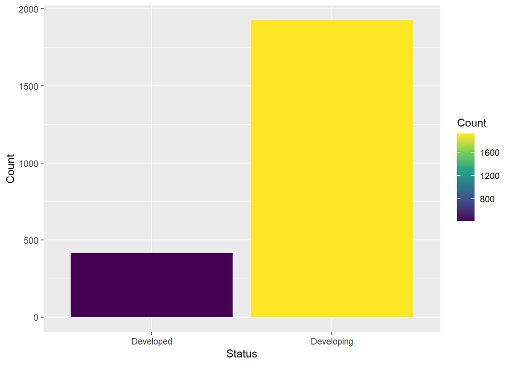

```r
train_data %>%
  count(Status) %>%
  rename(Count = n) %>%
  ggplot(aes(x=Status, y=Count)) +
  geom_histogram(stat="identity", aes(fill=Count)) +
  scale_fill_viridis_c()
```

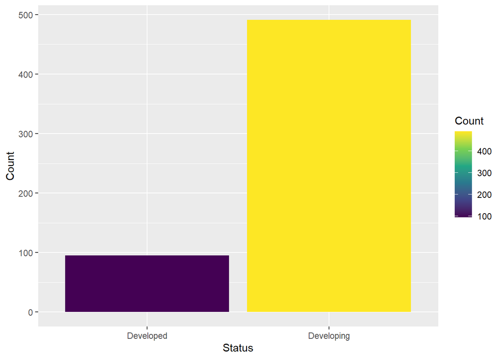

```r
test_data %>%
  count(Status) %>%
  rename(Count = n) %>%
  ggplot(aes(x=Status, y=Count)) +
  geom_histogram(stat="identity", aes(fill=Count)) +
  scale_fill_viridis_c()
```

Drop NA rows pre použité stĺpce v modeli, kvôli prevencii proti odstráneniu počas predikcii:

```r
test_data %<>%
  select(status_oh, `Life expectancy`, `Adult Mortality`, Alcohol,
         `percentage expenditure`, BMI, `Total expenditure`,
         Diphtheria, `HIV/AIDS`, GDP, `Income composition of resources`,
         Schooling) %>%
  drop_na()
```

# Experimenty

## Regressia:

### Hypotézy, ktoré sa nám zdajú zaujímavé:

#### H0 1. Výdavky na jedlo súvisia s GDP krajiny

Náš **response** variable bude **“percentage expenditure”** a **GDP** bude **prediktor**.

```r
# model
model = lm(`percentage expenditure` ~ GDP, data = train_data)
summary(model)
```

```
##
## Call:
## lm(formula = `percentage expenditure` ~ GDP, data = train_data)
##
## Residuals:
##     Min      1Q  Median      3Q     Max
## -8819.7   -20.9   114.9   142.2  8031.1
##
## Coefficients:
##               Estimate Std. Error t value Pr(>|t|)
## (Intercept) -1.403e+02  2.403e+01  -5.838 6.14e-09 ***
## GDP          1.350e-01  1.473e-03  91.702  < 2e-16 ***
## ---
## Signif. codes:  0 '***' 0.001 '**' 0.01 '*' 0.05 '.' 0.1 ' ' 1
##
## Residual standard error: 948.5 on 1985 degrees of freedom
##   (355 observations deleted due to missingness)
## Multiple R-squared:  0.809,  Adjusted R-squared:  0.8089
## F-statistic:  8409 on 1 and 1985 DF,  p-value: < 2.2e-16
```

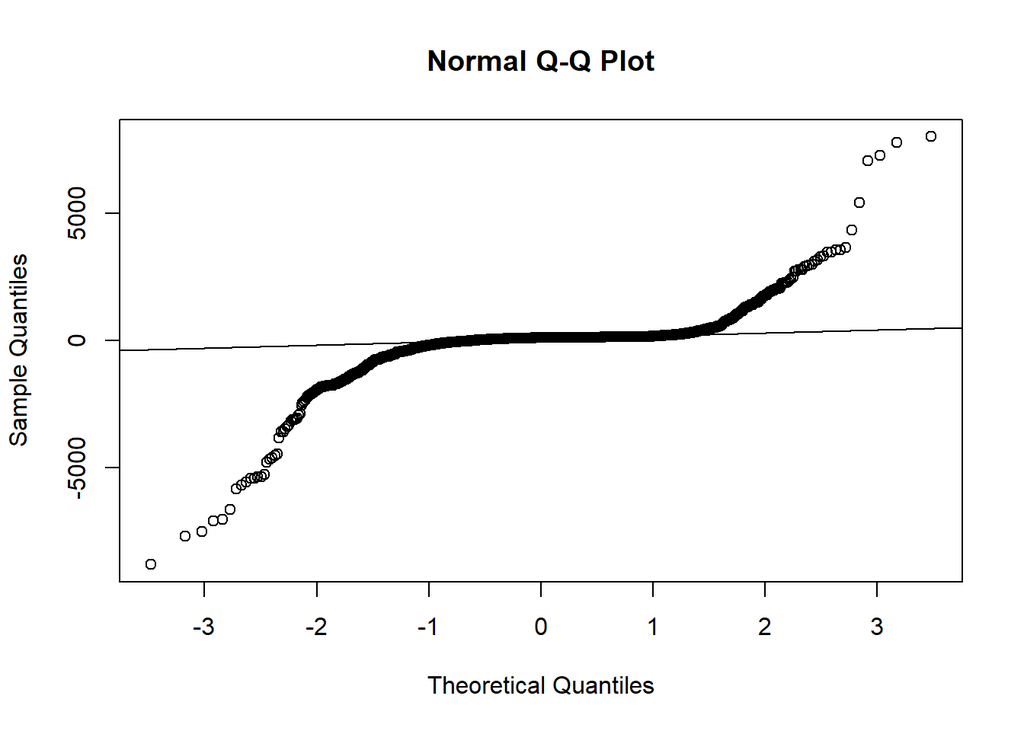

```r
qqnorm(model$residuals)
qqline(model$residuals)
```

```r
residuals <- model$residuals
RSS <- sum((residuals-mean(residuals))^2)
RSS
```

```
## [1] 1785839046
```

```r
RMSE <- sqrt(sum(((predict(model, test_data)) - test_data$`Life expectancy`)^2/length(test_data$`Life expectancy`)))
RMSE
```

```
## [1] 1999.928
```

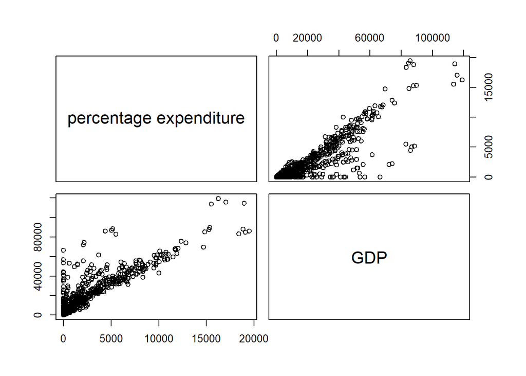

```r
data %$% pairs( ~ `percentage expenditure` + GDP)
```

Koeficient **GDP (0.135)** je štatisticky významný (p-hodnota < 0.001), čo naznačuje **pozitívnu** a **silnú** závislosť medzi **percentuálnymi výdavkami na jedlo a GDP krajiny**.

#### H0 2. Človek, ktorý sa dožíva dlhšieho veku má menej chorôb a nepije alkohol.

Náš **response** variable bude **“Life expectancy”** a ostatné stĺpce **(HIV/AIDS, Alcohol)** budú **prediktory**.

```r
# model
model = lm(`Life expectancy` ~ `HIV/AIDS` + Alcohol, data = train_data)
summary(model)
```

```
##
## Call:
## lm(formula = `Life expectancy` ~ `HIV/AIDS` + Alcohol, data = train_data)
##
## Residuals:
##     Min      1Q  Median      3Q     Max
## -33.867  -4.112   0.541   5.046  24.450
##
## Coefficients:
##             Estimate Std. Error t value Pr(>|t|)
## (Intercept) 67.03310    0.23278  287.97   <2e-16 ***
## `HIV/AIDS`  -1.00015    0.02878  -34.75   <2e-16 ***
## Alcohol      0.87392    0.03657   23.89   <2e-16 ***
## ---
## Signif. codes:  0 '***' 0.001 '**' 0.01 '*' 0.05 '.' 0.1 ' ' 1
##
## Residual standard error: 6.981 on 2191 degrees of freedom
##   (148 observations deleted due to missingness)
## Multiple R-squared:  0.4618, Adjusted R-squared:  0.4613
## F-statistic: 939.9 on 2 and 2191 DF,  p-value: < 2.2e-16
```

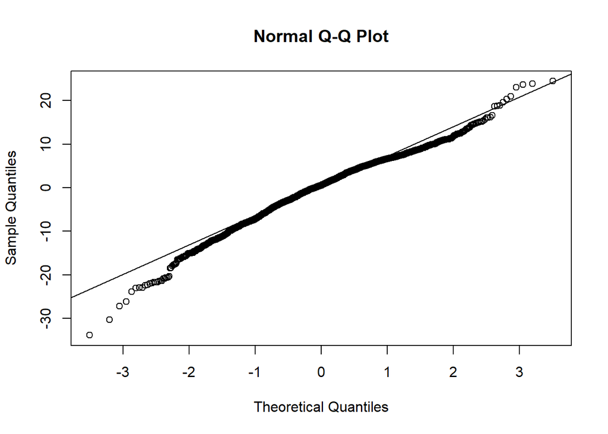

```r
qqnorm(model$residuals)
qqline(model$residuals)
```

```r
residuals <- model$residuals
RSS <- sum((residuals-mean(residuals))^2)
RSS
```

```
## [1] 106782.8
```

```r
RMSE <- sqrt(sum(((predict(model, test_data)) - test_data$`Life expectancy`)^2/length(test_data$`Life expectancy`)))
RMSE
```

```
## [1] 7.304382
```

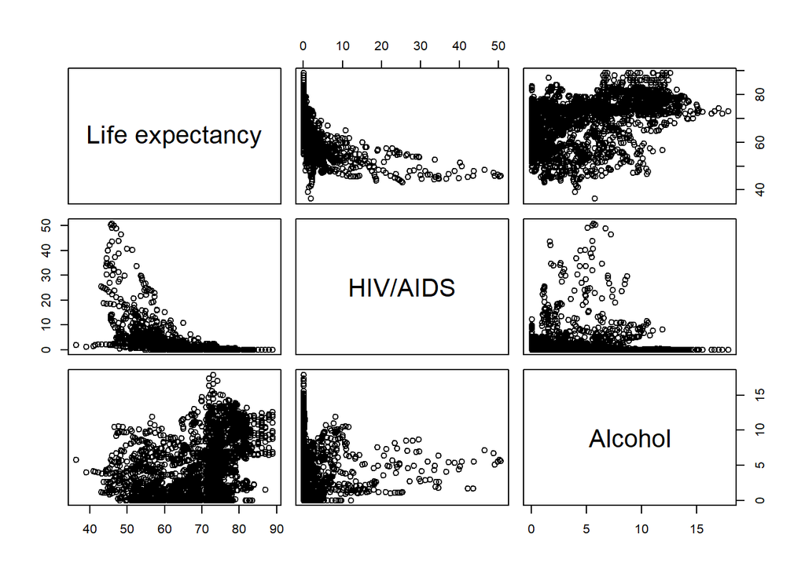

```r
data %$% pairs( ~ `Life expectancy` + `HIV/AIDS`+ Alcohol)
```

#### H0 3. Človek, ktorý žije v krajinách s vyšším GDP sa dožíva dlhšieho veku.

Náš **response** variable bude **“Life expectancy”** a **GDP** bude **prediktor**.

```r
# model
model = lm(`Life expectancy` ~ GDP, data = train_data)
summary(model)
```

```
##
## Call:
## lm(formula = `Life expectancy` ~ GDP, data = train_data)
##
## Residuals:
##     Min      1Q  Median      3Q     Max
## -31.017  -4.913   1.963   5.822  21.758
##
## Coefficients:
##              Estimate Std. Error t value Pr(>|t|)
## (Intercept) 6.711e+01  2.160e-01  310.68   <2e-16 ***
## GDP         3.065e-04  1.324e-05   23.16   <2e-16 ***
## ---
## Signif. codes:  0 '***' 0.001 '**' 0.01 '*' 0.05 '.' 0.1 ' ' 1
##
## Residual standard error: 8.526 on 1985 degrees of freedom
##   (355 observations deleted due to missingness)
## Multiple R-squared:  0.2127, Adjusted R-squared:  0.2123
## F-statistic: 536.2 on 1 and 1985 DF,  p-value: < 2.2e-16
```

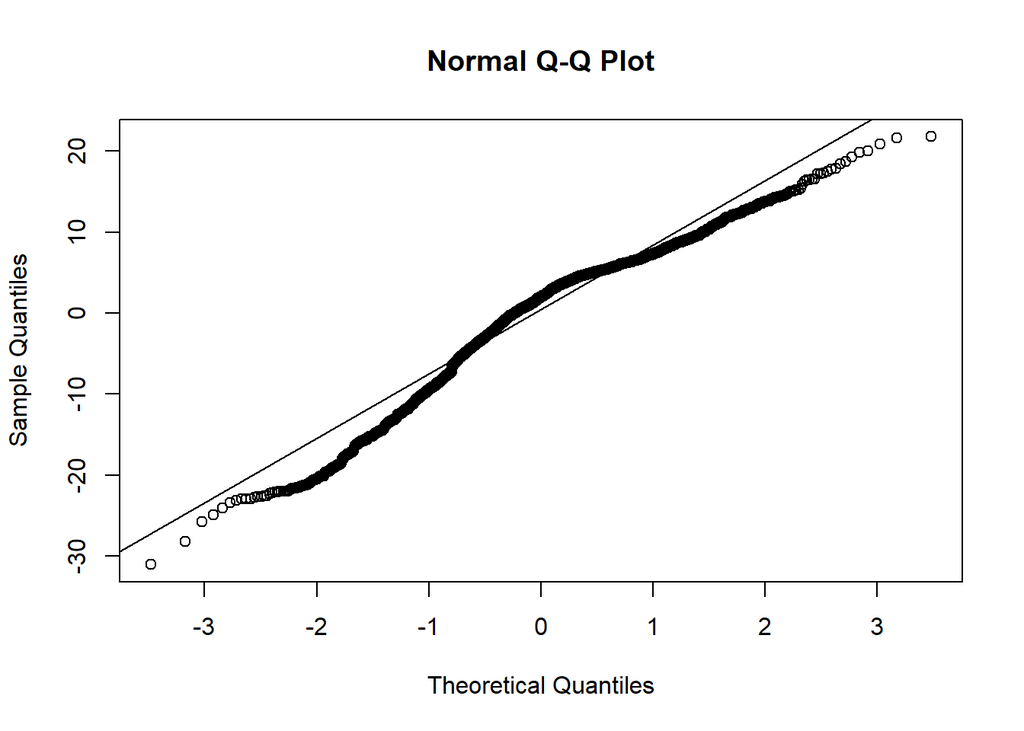

```r
qqnorm(model$residuals)
qqline(model$residuals)
```

```r
residuals <- model$residuals
RSS <- sum((residuals-mean(residuals))^2)
RSS
```

```
## [1] 144285
```

```r
RMSE <- sqrt(sum(((predict(model, test_data)) - test_data$`Life expectancy`)^2/length(test_data$`Life expectancy`)))
RMSE
```

```
## [1] 8.731909
```

Koeficient pre **GDP je 0.0003065**, čo znamená, že každý nárast o jednu jednotku v GDP krajiny sa očakáva, že priemerný vek sa **predĺži** o **0.0003065 rokov**. Tento koeficient je štatisticky významný (p-hodnota < 0.001), čo naznačuje **pozitívnu** závislosť medzi **GDP krajiny a dĺžkou života**. Q-Q plot ukazuje, že reziduá **nie sú z normálneho rozdelenia**, ale vidime, ze sa zhoduju s priamkou omnoho viac ako v prvom experimente. Suma štvorcov reziduí (RSS) je **144285** RMSE, čo je štandardná miera presnosti modelu, je približne **8.731909**. **Potvrdila** sa hypotéza, že **človek, ktorý žije v krajinách s vyšším GDP, sa dožíva dlhšieho veku**.

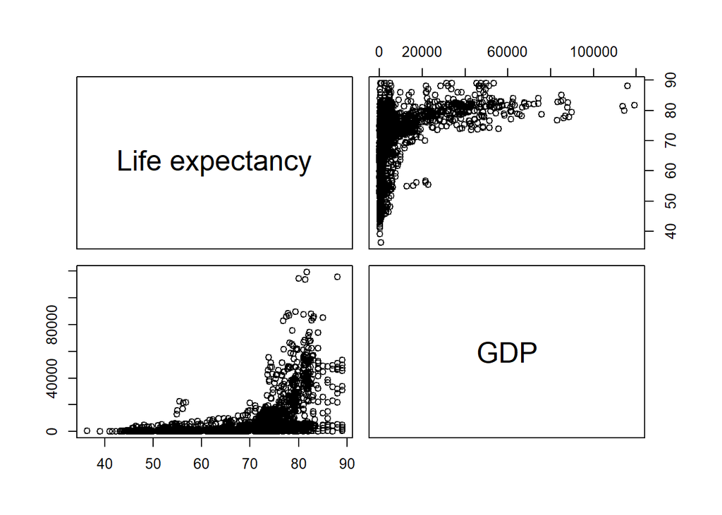

```r
data %$% pairs( ~ `Life expectancy` + GDP)
```

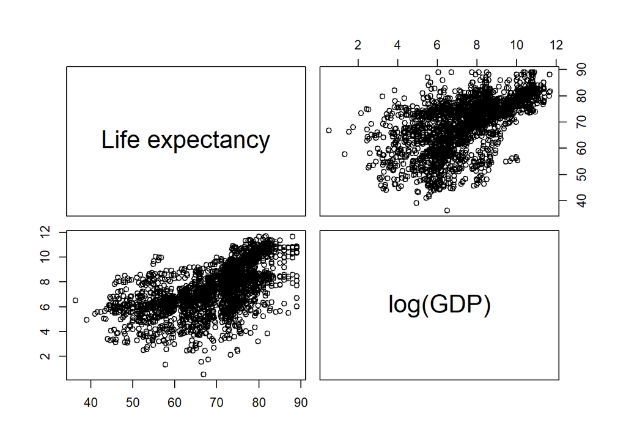

```r
data %$% pairs( ~ `Life expectancy` + log(GDP))
```

```r
model = lm(`Life expectancy` ~ log(GDP), data = train_data)
summary(model)
```

```
##
## Call:
## lm(formula = `Life expectancy` ~ log(GDP), data = train_data)
##
## Residuals:
##      Min       1Q   Median       3Q      Max
## -30.2320  -3.4081   0.8503   4.7113  23.8542
##
## Coefficients:
##             Estimate Std. Error t value Pr(>|t|)
## (Intercept) 47.10941    0.70793   66.55   <2e-16 ***
## log(GDP)     2.99007    0.09188   32.54   <2e-16 ***
## ---
## Signif. codes:  0 '***' 0.001 '**' 0.01 '*' 0.05 '.' 0.1 ' ' 1
##
## Residual standard error: 7.759 on 1985 degrees of freedom
##   (355 observations deleted due to missingness)
## Multiple R-squared:  0.3479, Adjusted R-squared:  0.3476
## F-statistic:  1059 on 1 and 1985 DF,  p-value: < 2.2e-16
```

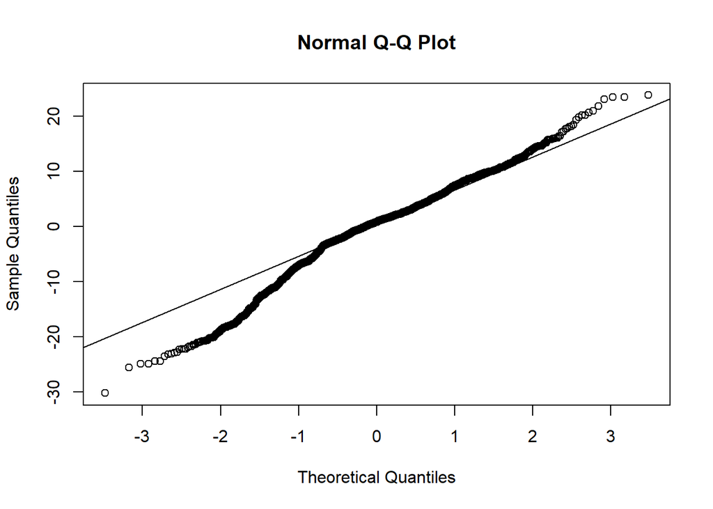

```r
qqnorm(model$residuals)
qqline(model$residuals)
```

```r
residuals <- model$residuals
RSS <- sum((residuals-mean(residuals))^2)
RSS
```

```
## [1] 119507.7
```

```r
RMSE <- sqrt(sum(((predict(model, test_data)) - test_data$`Life expectancy`)^2/length(test_data$`Life expectancy`)))
RMSE
```

```
## [1] 7.621577
```

Vidíme z **pairplotu**, že závislosť **Life expectancy** od **GDP** je **exponenciálna**. Preto sme **GDP** v tomto experimente skúsili **zlogaritmovať** - transformácia. Vidíme, aj na pairplote, že závislosť je rovnejšia, a aj hodnota **RMSE** je na **zlogaritmovanom** modeli **nižšia**.

#### H0 4. človek, ktorý dlhšie študuje a je viac vzdelaný sa dožíva dlhšieho veku v súvislosti s alkoholom.

Náš **response** variable bude **“Life expectancy”** a ostatné stĺpce **(Schooling,Alcohol)** budú prediktory.

```r
# model
model = lm(`Life expectancy` ~ Schooling + Alcohol, data = train_data)
summary(model)
```

```
##
## Call:
## lm(formula = `Life expectancy` ~ Schooling + Alcohol, data = train_data)
##
## Residuals:
##     Min      1Q  Median      3Q     Max
## -25.495  -2.895   0.694   3.855  31.795
##
## Coefficients:
##             Estimate Std. Error t value Pr(>|t|)
## (Intercept) 43.39073    0.54816  79.157   <2e-16 ***
## Schooling    2.18813    0.05056  43.274   <2e-16 ***
## Alcohol     -0.07186    0.04074  -1.764   0.0778 .
## ---
## Signif. codes:  0 '***' 0.001 '**' 0.01 '*' 0.05 '.' 0.1 ' ' 1
##
## Residual standard error: 6.27 on 2068 degrees of freedom
##   (271 observations deleted due to missingness)
## Multiple R-squared:  0.5517, Adjusted R-squared:  0.5513
## F-statistic:  1273 on 2 and 2068 DF,  p-value: < 2.2e-16
```

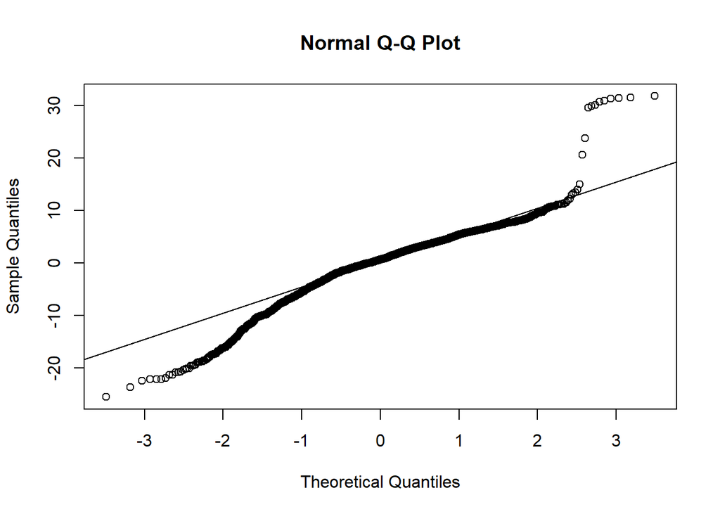

```r
qqnorm(model$residuals)
qqline(model$residuals)
```

```r
residuals <- model$residuals
RSS <- sum((residuals-mean(residuals))^2)
RSS
```

```
## [1] 81301.79
```

```r
RMSE <- sqrt(sum(((predict(model, test_data)) - test_data$`Life expectancy`)^2/length(test_data$`Life expectancy`)))
RMSE
```

```
## [1] 6.169674
```

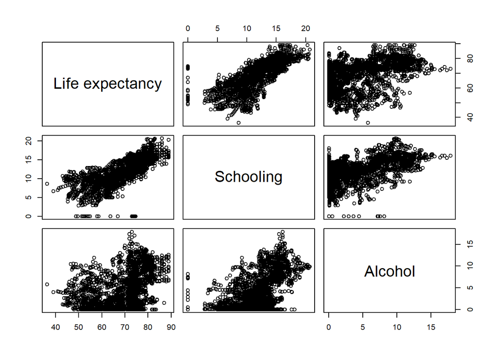

```r
data %$% pairs( ~ `Life expectancy` + Schooling + Alcohol)
```

Koeficient pre **Schooling je 2.18813** a **Alcohol -0.07186**. Koeficient pre Schooling je štatisticky významný (p-hodnota < 0.001), čo naznačuje, že štúdium má **pozitívny** vplyv na **očakávanú dĺžku života**. Naopak, koeficient pre **Alcohol nie je štatisticky významný na úrovni 0,05** (p-hodnota = 0.078), čo hovorí, že **neexistuje jasný dôkaz o vplyve alkoholu na dĺžku života**.

Q-Q plot ukazuje, že reziduá **nie sú z normálneho rozdelenia**, pretože sa nezhodujú s priamkou. Môže byť napr. z logistickej distribúcie.Suma štvorcov reziduí (RSS) je **81301.79**. RMSE, čo je štandardná miera presnosti modelu, je **6.169674**.

**Hypotéza sa potvrdila len čiastočne**, že **človek, ktorý dlhšie študuje a je viac vzdelaný sa dožíva dlhšieho veku. Alkohol nemá vplyv na dĺžku života v súvislosti so štúdiom.**

### Všetky prediktory

```r
# model
model = lm(`Life expectancy` ~ `Adult Mortality` + Alcohol  +
             `percentage expenditure` + BMI +
             `Total expenditure` + Diphtheria + `HIV/AIDS` + GDP +
             `Income composition of resources` +
             Schooling, data = train_data)
summary(model)
```

```
##
## Call:
## lm(formula = `Life expectancy` ~ `Adult Mortality` + Alcohol +
##     `percentage expenditure` + BMI + `Total expenditure` + Diphtheria +
##     `HIV/AIDS` + GDP + `Income composition of resources` + Schooling,
##     data = train_data)
##
## Residuals:
##      Min       1Q   Median       3Q      Max
## -21.0282  -2.2036  -0.0226   2.2988  21.8561
##
## Coefficients:
##                                     Estimate Std. Error t value Pr(>|t|)
## (Intercept)                        5.037e+01  5.636e-01  89.376   <2e-16 ***
## `Adult Mortality`                 -1.595e-02  9.840e-04 -16.213   <2e-16 ***
## Alcohol                           -4.347e-02  2.908e-02  -1.495   0.1352
## `percentage expenditure`           2.256e-04  1.119e-04   2.016   0.0439 *
## BMI                                5.067e-02  6.065e-03   8.354   <2e-16 ***
## `Total expenditure`                2.892e-02  4.231e-02   0.683   0.4944
## Diphtheria                         4.647e-02  4.584e-03  10.139   <2e-16 ***
## `HIV/AIDS`                        -4.957e-01  2.082e-02 -23.805   <2e-16 ***
## GDP                                3.066e-05  1.725e-05   1.778   0.0756 .
## `Income composition of resources`  7.311e+00  7.514e-01   9.729   <2e-16 ***
## Schooling                          9.669e-01  5.394e-02  17.927   <2e-16 ***
## ---
## Signif. codes:  0 '***' 0.001 '**' 0.01 '*' 0.05 '.' 0.1 ' ' 1
##
## Residual standard error: 4.051 on 1832 degrees of freedom
##   (499 observations deleted due to missingness)
## Multiple R-squared:  0.8256, Adjusted R-squared:  0.8247
## F-statistic: 867.4 on 10 and 1832 DF,  p-value: < 2.2e-16
```

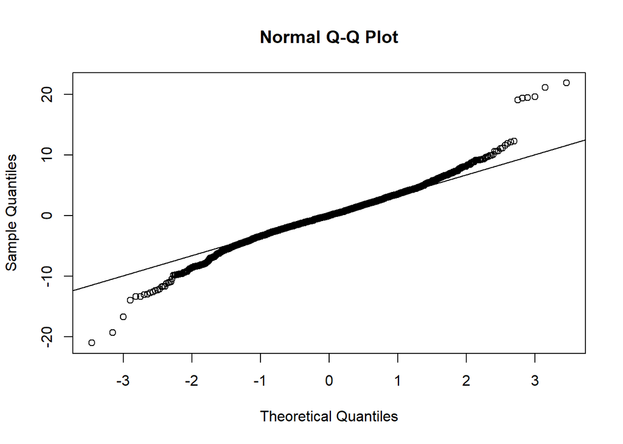

```r
qqnorm(model$residuals)
qqline(model$residuals)
```

```r
residuals <- model$residuals
RSS <- sum((residuals-mean(residuals))^2)
RSS
```

```
## [1] 30069.36
```

```r
RMSE <- sqrt(sum(((predict(model, test_data)) - test_data$`Life expectancy`)^2/length(test_data$`Life expectancy`)))
RMSE
```

```
## [1] 3.962512
```

Záporné koeficienty **(ako Adult Mortality, Alcohol a HIV/AIDS)** naznačujú **negatívnu** závislosť na **Life expectancy**, zatiaľ čo pozitívne koeficienty **(ako BMI, Diphtheria, percentage expenditure, total expenditure,GDP, Income composition of resources a Schooling)** naznačujú **pozitívnu** závislosť na **Life expectancy**. Hviezdičky pred hodnotami p-value znamenaju, že sä signifikantné.

## Classification:

### Hypotézy, ktoré sa nám zdajú zaujímavé:

#### H0 1. GDP a Schooling suvisí s tým, či je krajina rozvojová alebo rozvinutá.

#### H0 1. GDP a percentage expenditure suvisí s tým, či je krajina rozvojová alebo rozvinutá.

K-fold cross validácia aplikovaná na klassifikáciu, kde **response** variable bude **“status_oh”** a ostatné stĺpce **(GDP, Schooling)** budú **prediktory**. Použitý naive bayes model. #TODO poskusat aj ine a porovnat vyseldky vez tohoto K-fold??

```r
set.seed(123)
# one-hot encoding column status
data$status_oh <- as.factor(data$status_oh)

train_control <- trainControl(method = "cv",
                              number = 10)

#remove NA values
data <- na.omit(data)

#model
model <- train(status_oh ~ Schooling + GDP, data = data,
               trControl = train_control,
               method = "nb")

print(model)
```

```
## Naive Bayes
##
## 1649 samples
##    2 predictor
##    2 classes: '0', '1'
##
## No pre-processing
## Resampling: Cross-Validated (10 fold)
## Summary of sample sizes: 1484, 1484, 1483, 1485, 1484, 1485, ...
## Resampling results across tuning parameters:
##
##   usekernel  Accuracy   Kappa
##   FALSE      0.8835680  0.4583700
##    TRUE      0.8884056  0.5357178
##
## Tuning parameter 'fL' was held constant at a value of 0
## Tuning
##  parameter 'adjust' was held constant at a value of 1
## Accuracy was used to select the optimal model using the largest value.
## The final values used for the model were fL = 0, usekernel = TRUE and adjust
##  = 1.
```

Použitie kernelu má pozitivny vpliv na presnosť modelu.

Podľa korelácie vybraté prediktory **GDP a percentage expenditure** súvisia s **rozvojovým statusom krajiny**:

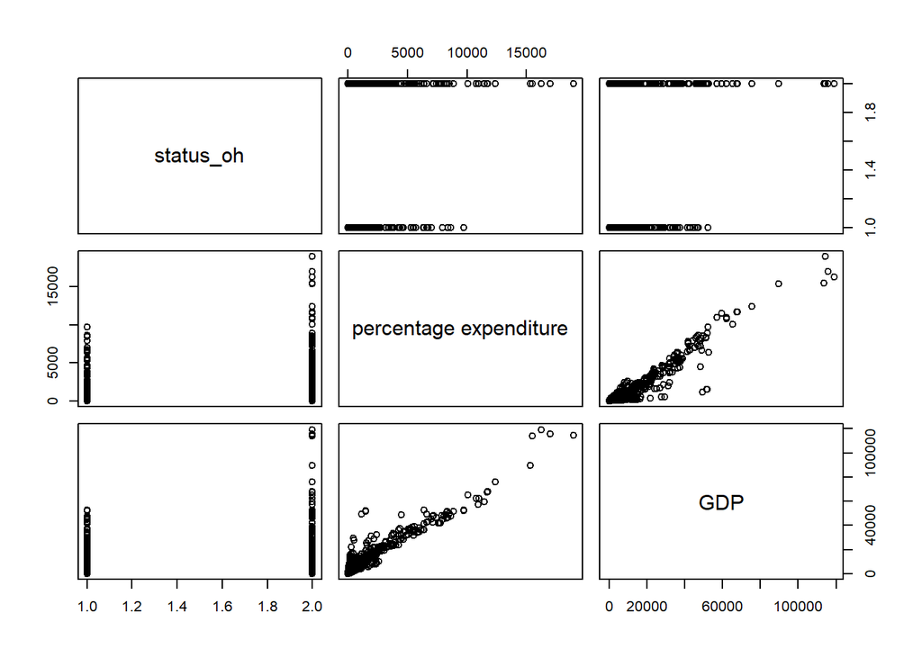

```r
data %$% pairs( status_oh ~  `percentage expenditure` + GDP)
```

1. experiment: Náš **response** variable bude **“status_oh”** a ostatné stĺpce **(GDP, Schooling)** budú **prediktory**.

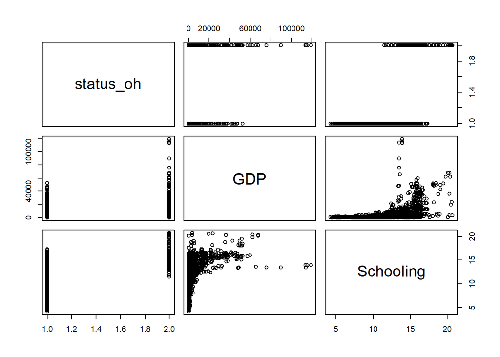

```r
data %$% pairs( status_oh ~  GDP + Schooling)
```

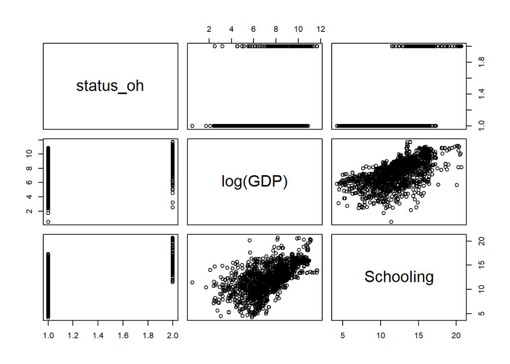

```r
data %$% pairs( status_oh ~  log(GDP) + Schooling)
```

```r
# model
model = glm(status_oh ~ GDP + Schooling, data = train_data)
summary(model)
```

```
##
## Call:
## glm(formula = status_oh ~ GDP + Schooling, data = train_data)
##
## Coefficients:
##               Estimate Std. Error t value Pr(>|t|)
## (Intercept) -4.332e-01  2.744e-02  -15.78   <2e-16 ***
## GDP          8.141e-06  5.353e-07   15.21   <2e-16 ***
## Schooling    4.563e-02  2.318e-03   19.68   <2e-16 ***
## ---
## Signif. codes:  0 '***' 0.001 '**' 0.01 '*' 0.05 '.' 0.1 ' ' 1
##
## (Dispersion parameter for gaussian family taken to be 0.09585405)
##
##     Null deviance: 294.68  on 1983  degrees of freedom
## Residual deviance: 189.89  on 1981  degrees of freedom
##   (358 observations deleted due to missingness)
## AIC: 983.01
##
## Number of Fisher Scoring iterations: 2
```

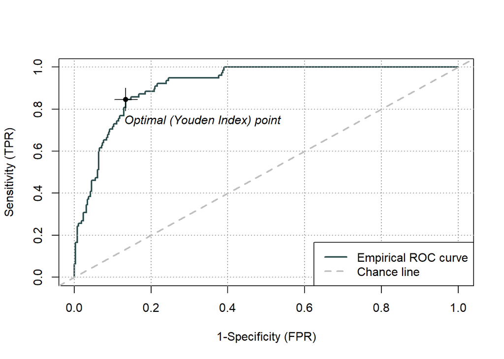

```r
predictions <- predict(model, test_data)

actual <- test_data$status_oh

# výpočet cut off hodnoty, ktorý naznačuje optimálny bod pre prahovu hodnotu, ktorá rozdeľuje predikcie na pozitívne a negatívne, čiže rozvojovú a rozvinutú krajinu.

roc = rocit(predictions, actual)
plot(roc)
```

```r
cutoff_index <- which.max(roc$TPR + (1 - roc$FPR) - 1)
optimal_cutoff <- roc$Cutoff[cutoff_index]
optimal_cutoff
```

```
## [1] 0.275745
```

```r
predicted_class <- ifelse(predictions >= optimal_cutoff, 1, 0)

# confussion matrix
caret::confusionMatrix(as.factor(predicted_class), as.factor(actual), positive = "1")
```

```
## Confusion Matrix and Statistics
##
##           Reference
## Prediction   0   1
##          0 329  12
##          1  51  66
##
##                Accuracy : 0.8624
##                  95% CI : (0.8275, 0.8927)
##     No Information Rate : 0.8297
##     P-Value [Acc > NIR] : 0.03313
##
##                   Kappa : 0.5939
##
##  Mcnemar's Test P-Value : 1.688e-06
##
##             Sensitivity : 0.8462
##             Specificity : 0.8658
##          Pos Pred Value : 0.5641
##          Neg Pred Value : 0.9648
##              Prevalence : 0.1703
##          Detection Rate : 0.1441
##    Detection Prevalence : 0.2555
##       Balanced Accuracy : 0.8560
##
##        'Positive' Class : 1
##
```

Celkovo model naznačuje, že **GDP a školstvo** sú **významnými prediktormi rozvojového statusu krajiny**, pričom **vyššie GDP a úroveň školstva sú spojené s vyššou pravdepodobnosťou byť rozvinutou krajinou**. Spravili sme cross tabulaciu a z confusion matrix vidíme, že náš model má **86,24%** presnosť.

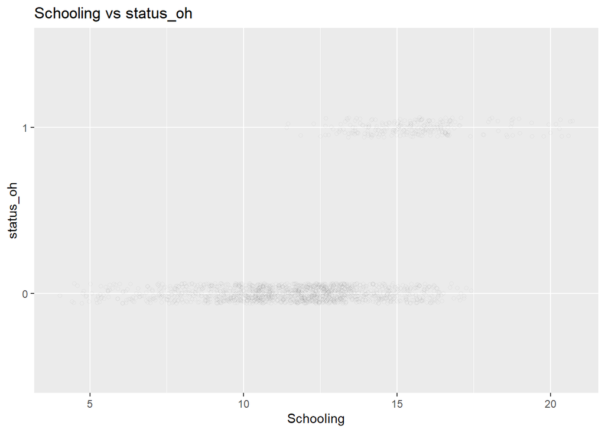

```r
data %>%
  ggplot(., aes(x = Schooling, y = status_oh)) +  # Specify X and Y variables
  geom_point(position = position_jitter(width = 0.3, height = 0.06),
             alpha = 0.05,
             shape = 1,
             size = 1.5) +
  stat_smooth(method = glm, method.args = list(family = binomial)) +
  ggtitle("Schooling vs status_oh")
```

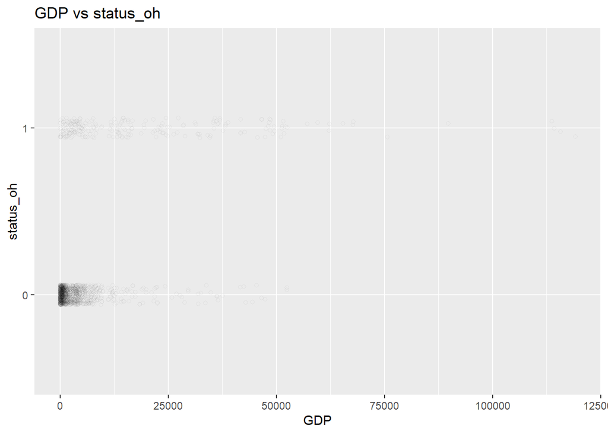

```r
data %>%
  ggplot(., aes(x = GDP, y = status_oh)) +  # Specify X and Y variables
  geom_point(position = position_jitter(width = 0.3, height = 0.06),
             alpha = 0.05,
             shape = 1,
             size = 1.5) +
  stat_smooth(method = glm, method.args = list(family = binomial)) +
  ggtitle("GDP vs status_oh")
```

# Radial SVM metóda

```r
library(e1071)

# Model
svm_model <- svm(status_oh ~ GDP + Schooling, data = train_data, kernel = "radial")
summary(svm_model)
```

```
##
## Call:
## svm(formula = status_oh ~ GDP + Schooling, data = train_data, kernel = "radial")
##
##
## Parameters:
##    SVM-Type:  eps-regression
##  SVM-Kernel:  radial
##        cost:  1
##       gamma:  0.5
##     epsilon:  0.1
##
##
## Number of Support Vectors:  563
```

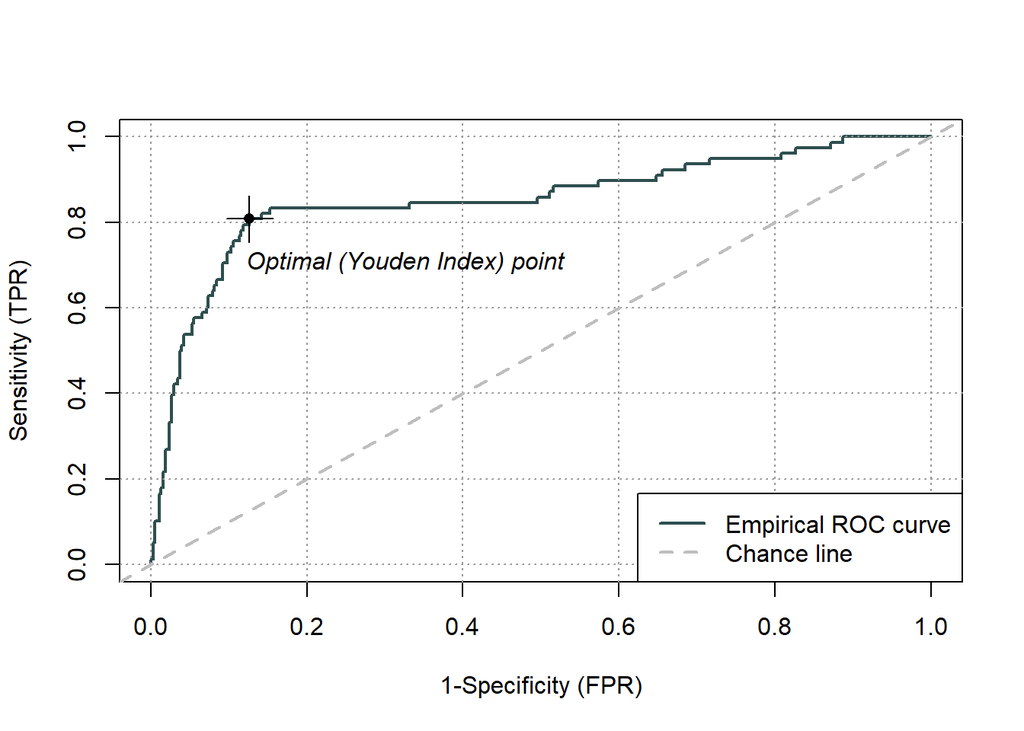

```r
# Predictions
svm_predictions <- predict(svm_model, test_data)

actual <- test_data$status_oh
roc_svm_rad = rocit(svm_predictions, actual)
plot(roc_svm_rad)
```

```r
cutoff_index <- which.max(roc_svm_rad$TPR + (1 - roc_svm_rad$FPR) - 1)
optimal_cutoff <- roc_svm_rad$Cutoff[cutoff_index]
optimal_cutoff
```

```
## [1] 0.07671337
```

```r
predicted_class_svm_rad <- ifelse(svm_predictions >= optimal_cutoff, 1, 0)

# Confusion matrix
confusionMatrix(as.factor(predicted_class_svm_rad), as.factor(test_data$status_oh))
```

```
## Confusion Matrix and Statistics
##
##           Reference
## Prediction   0   1
##          0 332  15
##          1  48  63
##
##                Accuracy : 0.8624
##                  95% CI : (0.8275, 0.8927)
##     No Information Rate : 0.8297
##     P-Value [Acc > NIR] : 0.03313
##
##                   Kappa : 0.5833
##
##  Mcnemar's Test P-Value : 5.539e-05
##
##             Sensitivity : 0.8737
##             Specificity : 0.8077
##          Pos Pred Value : 0.9568
##          Neg Pred Value : 0.5676
##              Prevalence : 0.8297
##          Detection Rate : 0.7249
##    Detection Prevalence : 0.7576
##       Balanced Accuracy : 0.8407
##
##        'Positive' Class : 0
##
```

Accuracy je 86,24%.

# Linear SVM metóda

```r
# Model
svm_model <- svm(status_oh ~ GDP + Schooling, data = train_data, kernel = "linear")
summary(svm_model)
```

```
##
## Call:
## svm(formula = status_oh ~ GDP + Schooling, data = train_data, kernel = "linear")
##
##
## Parameters:
##    SVM-Type:  eps-regression
##  SVM-Kernel:  linear
##        cost:  1
##       gamma:  0.5
##     epsilon:  0.1
##
##
## Number of Support Vectors:  847
```

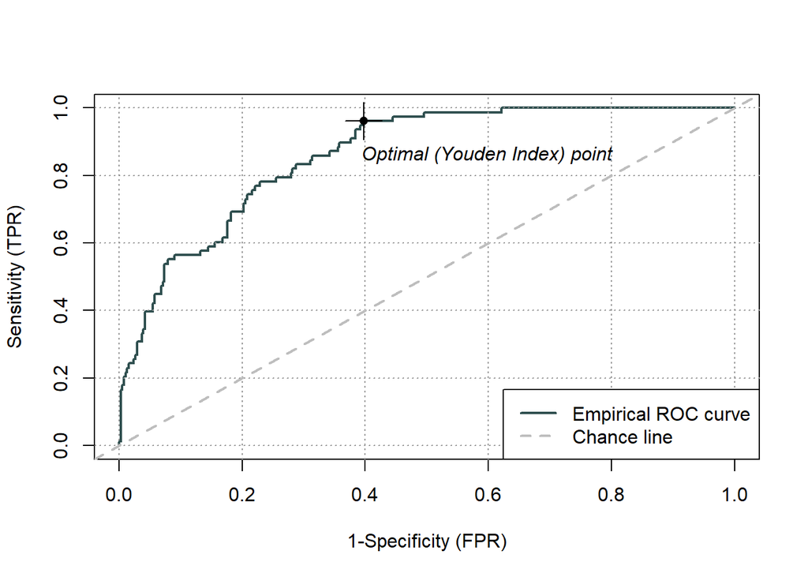

```r
# Predictions
svm_predictions <- predict(svm_model, test_data)

actual <- test_data$status_oh

roc_svm_ln = rocit(svm_predictions, actual)
plot(roc_svm_ln)
```

```r
cutoff_index <- which.max(roc_svm_ln$TPR + (1 - roc_svm_ln$FPR) - 1)
optimal_cutoff <- roc_svm_ln$Cutoff[cutoff_index]
optimal_cutoff
```

```
## [1] 0.003257604
```

```r
predicted_class_svm_ln <- ifelse(svm_predictions >= optimal_cutoff, 1, 0)

# Confusion matrix
confusionMatrix(as.factor(predicted_class_svm_ln), as.factor(test_data$status_oh))
```

```
## Confusion Matrix and Statistics
##
##           Reference
## Prediction   0   1
##          0 229   3
##          1 151  75
##
##                Accuracy : 0.6638
##                  95% CI : (0.6184, 0.7069)
##     No Information Rate : 0.8297
##     P-Value [Acc > NIR] : 1
##
##                   Kappa : 0.3217
##
##  Mcnemar's Test P-Value : <2e-16
##
##             Sensitivity : 0.6026
##             Specificity : 0.9615
##          Pos Pred Value : 0.9871
##          Neg Pred Value : 0.3319
##              Prevalence : 0.8297
##          Detection Rate : 0.5000
##    Detection Prevalence : 0.5066
##       Balanced Accuracy : 0.7821
##
##        'Positive' Class : 0
##
```

```r
#predicted <- predict(svm_model,data)
#confusionMatrix(table(predicted, data$status_oh))
```

Accuracy je 66,38%.

# Naive Bayes metóda

```r
# Model
nb_model <- naiveBayes(status_oh ~ GDP + Schooling, data = train_data)
summary(nb_model)
```

```
##           Length Class  Mode
## apriori   2      table  numeric
## tables    2      -none- list
## levels    2      -none- character
## isnumeric 2      -none- logical
## call      4      -none- call
```

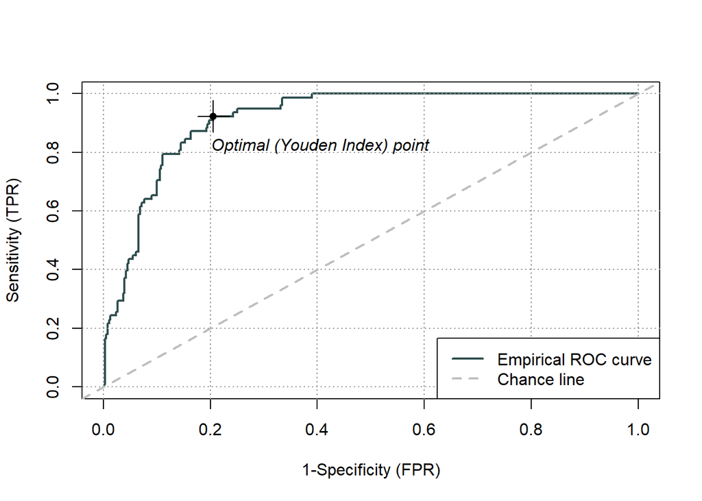

```r
# Predictions
nb_predictions <- predict(nb_model, newdata = test_data, type = "raw")

actual <- test_data$status_oh

roc_nb = rocit(nb_predictions[, 2], actual)
plot(roc_nb)
```

```r
cutoff_index <- which.max(roc_nb$TPR - roc_nb$FPR)
optimal_cutoff <- roc_nb$Cutoff[cutoff_index]

predicted_class_nb <- ifelse(nb_predictions[, 2] >= optimal_cutoff, 1, 0)

confusionMatrix(as.factor(predicted_class_nb), as.factor(test_data$status_oh))
```

```
## Confusion Matrix and Statistics
##
##           Reference
## Prediction   0   1
##          0 302   6
##          1  78  72
##
##                Accuracy : 0.8166
##                  95% CI : (0.7781, 0.851)
##     No Information Rate : 0.8297
##     P-Value [Acc > NIR] : 0.7918
##
##                   Kappa : 0.5252
##
##  Mcnemar's Test P-Value : 9.429e-15
##
##             Sensitivity : 0.7947
##             Specificity : 0.9231
##          Pos Pred Value : 0.9805
##          Neg Pred Value : 0.4800
##              Prevalence : 0.8297
##          Detection Rate : 0.6594
##    Detection Prevalence : 0.6725
##       Balanced Accuracy : 0.8589
##
##        'Positive' Class : 0
##
```

Accuracy je 81,66%.

## Random Forest ma problemy s chybajucimi hodnotammi v train_data, mozem ich omitnut

### gives me number of missing values in each column

```r
sapply(train_data, function(x) sum(is.na(x))) # chybajuce hodnoty v stlpcoch
```

```
##                       status_oh                         Country
##                               0                               0
##                            Year                          Status
##                               0                               0
##                 Life expectancy                 Adult Mortality
##                               0                               0
##                   infant deaths                         Alcohol
##                               0                             148
##          percentage expenditure                     Hepatitis B
##                               0                             446
##                         Measles                             BMI
##                               0                              26
##               under-five deaths                           Polio
##                               0                              13
##               Total expenditure                      Diphtheria
##                             176                              13
##                        HIV/AIDS                             GDP
##                               0                             355
##                      Population            thinness  1-19 years
##                             530                              26
##              thinness 5-9 years Income composition of resources
##                              26                             132
##                       Schooling                       Continent
##                             132                               0
```

```r
# count na data which will be omitted

nrow(na.omit(train_data))
```

```
## [1] 1310
```

```r
train_data_rf = na.omit(train_data)
```

# Random Forest metóda

```r
#install.packages("randomForest")
library(randomForest)

# Model
rf_model <- randomForest(status_oh ~ GDP + Schooling, data = train_data_rf)
summary(rf_model)
```

```
##                 Length Class  Mode
## call               3   -none- call
## type               1   -none- character
## predicted       1310   -none- numeric
## mse              500   -none- numeric
## rsq              500   -none- numeric
## oob.times       1310   -none- numeric
## importance         2   -none- numeric
## importanceSD       0   -none- NULL
## localImportance    0   -none- NULL
## proximity          0   -none- NULL
## ntree              1   -none- numeric
## mtry               1   -none- numeric
## forest            11   -none- list
## coefs              0   -none- NULL
## y               1310   -none- numeric
## test               0   -none- NULL
## inbag              0   -none- NULL
## terms              3   terms  call
```

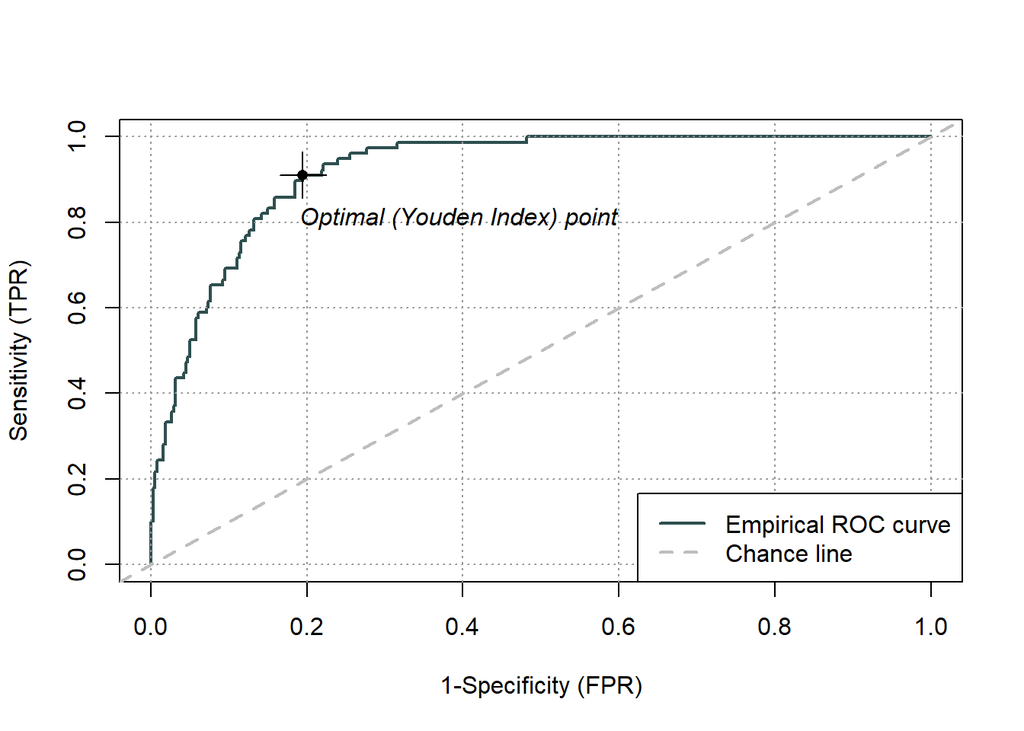

```r
# Predictions
rf_predictions <- predict(rf_model, test_data)

actual <- test_data$status_oh
roc_random_forrest = rocit(rf_predictions, actual)
plot(roc_random_forrest)
```

```r
cutoff_index <- which.max(roc_random_forrest$TPR + (1 - roc_random_forrest$FPR) - 1)
optimal_cutoff <- roc_random_forrest$Cutoff[cutoff_index]
optimal_cutoff
```

```
## [1] 0.115957
```

```r
predicted_class_randomm_forrest <- ifelse(rf_predictions >= optimal_cutoff, 1, 0)


confusionMatrix(as.factor(predicted_class_randomm_forrest), as.factor(test_data$status_oh))
```

```
## Confusion Matrix and Statistics
##
##           Reference
## Prediction   0   1
##          0 306   7
##          1  74  71
##
##                Accuracy : 0.8231
##                  95% CI : (0.7851, 0.857)
##     No Information Rate : 0.8297
##     P-Value [Acc > NIR] : 0.6722
##
##                   Kappa : 0.5334
##
##  Mcnemar's Test P-Value : 2.245e-13
##
##             Sensitivity : 0.8053
##             Specificity : 0.9103
##          Pos Pred Value : 0.9776
##          Neg Pred Value : 0.4897
##              Prevalence : 0.8297
##          Detection Rate : 0.6681
##    Detection Prevalence : 0.6834
##       Balanced Accuracy : 0.8578
##
##        'Positive' Class : 0
##
```

# LDA metóda

```r
library(MASS)

# Model
lda_model <- lda(status_oh ~ GDP + Schooling, data = train_data)
summary(lda_model)
```

```
##           Length Class  Mode
## prior       2    -none- numeric
## counts      2    -none- numeric
## means       4    -none- numeric
## scaling     2    -none- numeric
## lev         2    -none- character
## svd         1    -none- numeric
## N           1    -none- numeric
## call        3    -none- call
## terms       3    terms  call
## xlevels     0    -none- list
## na.action 358    omit   numeric
```

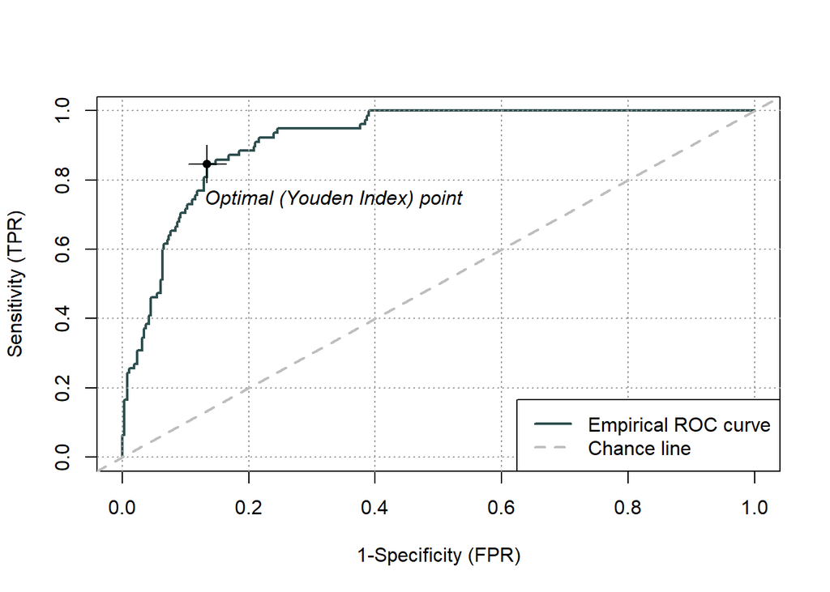

```r
# Predictions

lda_predictions <- predict(lda_model, newdata = test_data)$posterior[, "1"]

actual <- test_data$status_oh

roc_lda = rocit(lda_predictions, actual)
plot(roc_lda)
```

```r
cutoff_index <- which.max(roc_lda$TPR - roc_lda$FPR)
optimal_cutoff <- roc_lda$Cutoff[cutoff_index]

predicted_class_lda <- ifelse(lda_predictions >= optimal_cutoff, 1, 0)

confusionMatrix(as.factor(predicted_class_lda), as.factor(test_data$status_oh))
```

```
## Confusion Matrix and Statistics
##
##           Reference
## Prediction   0   1
##          0 329  12
##          1  51  66
##
##                Accuracy : 0.8624
##                  95% CI : (0.8275, 0.8927)
##     No Information Rate : 0.8297
##     P-Value [Acc > NIR] : 0.03313
##
##                   Kappa : 0.5939
##
##  Mcnemar's Test P-Value : 1.688e-06
##
##             Sensitivity : 0.8658
##             Specificity : 0.8462
##          Pos Pred Value : 0.9648
##          Neg Pred Value : 0.5641
##              Prevalence : 0.8297
##          Detection Rate : 0.7183
##    Detection Prevalence : 0.7445
##       Balanced Accuracy : 0.8560
##
##        'Positive' Class : 0
##
```

Accuracy je 86,24%. Podobne ako pri SVM-radial metóde.

## Model performance parameters v 1 tabuľke

```r
library(pROC)

test_data$status_oh <- as.factor(test_data$status_oh)

# Calculate performance metrics
data.frame(
  Model = c("GLM","LDA", "SVM-linear","SVM-radial", "Naive Bayes", "Random Forest"),
  Accuracy = c(
    confusionMatrix(as.factor(predicted_class), test_data$status_oh)$overall["Accuracy"],
    confusionMatrix(as.factor(predicted_class_lda), test_data$status_oh)$overall["Accuracy"],
    confusionMatrix(as.factor(predicted_class_svm_ln), test_data$status_oh)$overall["Accuracy"],
    confusionMatrix(as.factor(predicted_class_svm_rad), test_data$status_oh)$overall["Accuracy"],
    confusionMatrix(as.factor(predicted_class_nb), test_data$status_oh)$overall["Accuracy"],
    confusionMatrix(as.factor(predicted_class_randomm_forrest), test_data$status_oh)$overall["Accuracy"]
  ),
  Sensitivity = c(
    confusionMatrix(as.factor(predicted_class), test_data$status_oh)$byClass["Sensitivity"],
    confusionMatrix(as.factor(predicted_class_lda), test_data$status_oh)$byClass["Sensitivity"],
    confusionMatrix(as.factor(predicted_class_svm_ln), test_data$status_oh)$byClass["Sensitivity"],
    confusionMatrix(as.factor(predicted_class_svm_rad), test_data$status_oh)$byClass["Sensitivity"],
    confusionMatrix(as.factor(predicted_class_nb), test_data$status_oh)$byClass["Sensitivity"],
    confusionMatrix(as.factor(predicted_class_randomm_forrest), test_data$status_oh)$byClass["Sensitivity"]
  ),
  Specificity = c(
    confusionMatrix(as.factor(predicted_class), test_data$status_oh)$byClass["Specificity"],
    confusionMatrix(as.factor(predicted_class_lda), test_data$status_oh)$byClass["Specificity"],
    confusionMatrix(as.factor(predicted_class_svm_ln), test_data$status_oh)$byClass["Specificity"],
    confusionMatrix(as.factor(predicted_class_svm_rad), test_data$status_oh)$byClass["Specificity"],
    confusionMatrix(as.factor(predicted_class_nb), test_data$status_oh)$byClass["Specificity"],
    confusionMatrix(as.factor(predicted_class_randomm_forrest), test_data$status_oh)$byClass["Specificity"]
  ),
  F1_Score = c(
    confusionMatrix(as.factor(predicted_class), test_data$status_oh)$byClass["F1"],
    confusionMatrix(as.factor(predicted_class_lda), test_data$status_oh)$byClass["F1"],
    confusionMatrix(as.factor(predicted_class_svm_ln), test_data$status_oh)$byClass["F1"],
    confusionMatrix(as.factor(predicted_class_svm_rad), test_data$status_oh)$byClass["F1"],
    confusionMatrix(as.factor(predicted_class_nb), test_data$status_oh)$byClass["F1"],
    confusionMatrix(as.factor(predicted_class_randomm_forrest), test_data$status_oh)$byClass["F1"]
  ),
  AUC_ROC = c(
    roc(test_data$status_oh, as.numeric(predicted_class))$auc,
    roc(test_data$status_oh, as.numeric(predicted_class_lda))$auc,
    roc(test_data$status_oh, as.numeric(predicted_class_svm_ln))$auc,
    roc(test_data$status_oh, as.numeric(predicted_class_svm_rad))$auc,
    roc(test_data$status_oh, as.numeric(predicted_class_nb))$auc,
    roc(test_data$status_oh, as.numeric(predicted_class_randomm_forrest))$auc
  )
)
```

```
##           Model  Accuracy Sensitivity Specificity  F1_Score   AUC_ROC
## 1           GLM 0.8624454   0.8657895   0.8461538 0.9126214 0.8559717
## 2           LDA 0.8624454   0.8657895   0.8461538 0.9126214 0.8559717
## 3    SVM-linear 0.6637555   0.6026316   0.9615385 0.7483660 0.7820850
## 4    SVM-radial 0.8624454   0.8736842   0.8076923 0.9133425 0.8406883
## 5   Naive Bayes 0.8165939   0.7947368   0.9230769 0.8779070 0.8589069
## 6 Random Forest 0.8231441   0.8052632   0.9102564 0.8831169 0.8577598
```

### Logaritmovaný GDP - 2. experiment

```r
# model
model = glm(status_oh ~ log(GDP) + Schooling, data = train_data)
summary(model)
```

```
##
## Call:
## glm(formula = status_oh ~ log(GDP) + Schooling, data = train_data)
##
## Coefficients:
##              Estimate Std. Error t value Pr(>|t|)
## (Intercept) -0.686058   0.031614 -21.701  < 2e-16 ***
## log(GDP)     0.037535   0.004753   7.897 4.68e-15 ***
## Schooling    0.048460   0.002696  17.975  < 2e-16 ***
## ---
## Signif. codes:  0 '***' 0.001 '**' 0.01 '*' 0.05 '.' 0.1 ' ' 1
##
## (Dispersion parameter for gaussian family taken to be 0.1037765)
##
##     Null deviance: 294.68  on 1983  degrees of freedom
## Residual deviance: 205.58  on 1981  degrees of freedom
##   (358 observations deleted due to missingness)
## AIC: 1140.6
##
## Number of Fisher Scoring iterations: 2
```

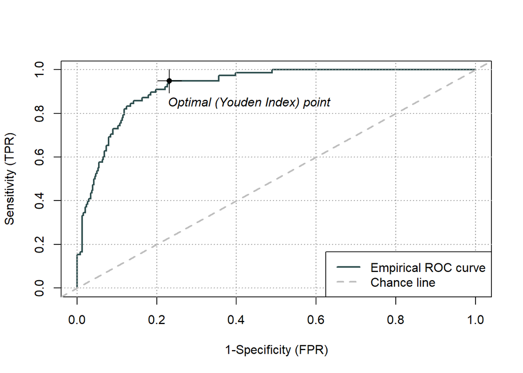

```r
predictions <- predict(model, test_data)

actual <- test_data$status_oh

# výpočet cut off hodnoty, ktorý naznačuje optimálny bod pre prahovu hodnotu, ktorá rozdeľuje predikcie na pozitívne a negatívne, čiže rozvojovú a rozvinutú krajinu.

roc = rocit(predictions, actual)
plot(roc)
```

```r
cutoff_index <- which.max(roc$TPR + (1 - roc$FPR) - 1)
optimal_cutoff <- roc$Cutoff[cutoff_index]
optimal_cutoff
```

```
## [1] 0.278461
```

```r
predicted_class <- ifelse(predictions >= optimal_cutoff, 1, 0)

# confussion matrix
caret::confusionMatrix(as.factor(predicted_class), as.factor(actual), positive = "1")
```

```
## Confusion Matrix and Statistics
##
##           Reference
## Prediction   0   1
##          0 292   4
##          1  88  74
##
##                Accuracy : 0.7991
##                  95% CI : (0.7595, 0.8349)
##     No Information Rate : 0.8297
##     P-Value [Acc > NIR] : 0.962
##
##                   Kappa : 0.5022
##
##  Mcnemar's Test P-Value : <2e-16
##
##             Sensitivity : 0.9487
##             Specificity : 0.7684
##          Pos Pred Value : 0.4568
##          Neg Pred Value : 0.9865
##              Prevalence : 0.1703
##          Detection Rate : 0.1616
##    Detection Prevalence : 0.3537
##       Balanced Accuracy : 0.8586
##
##        'Positive' Class : 1
##
```

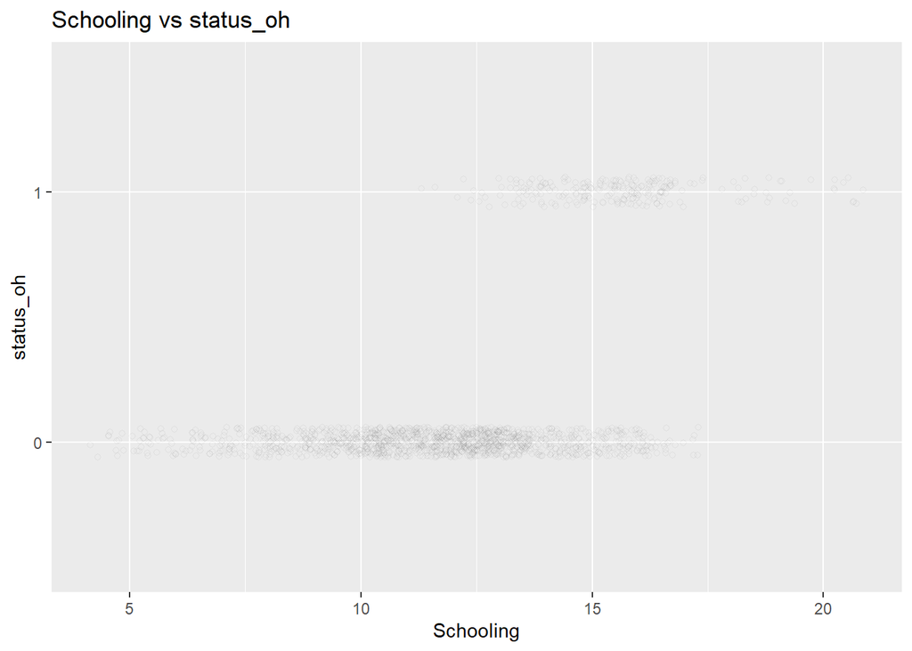

```r
data %>%
  ggplot(., aes(x = Schooling, y = status_oh)) +  # Specify X and Y variables
  geom_point(position = position_jitter(width = 0.3, height = 0.06),
             alpha = 0.05,
             shape = 1,
             size = 1.5) +
  stat_smooth(method = glm, method.args = list(family = binomial)) +
  ggtitle("Schooling vs status_oh")
```

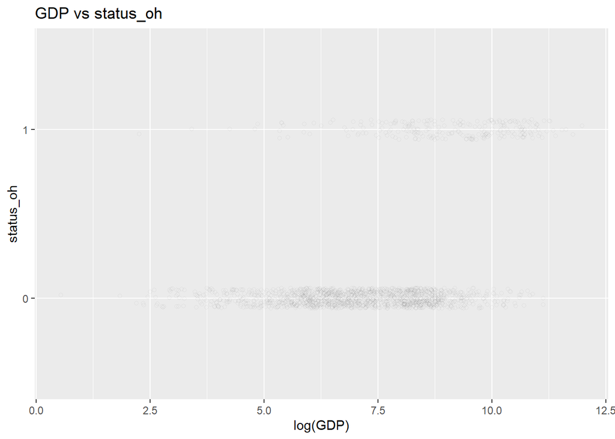

```r
data %>%
  ggplot(., aes(x = log(GDP), y = status_oh)) +  # Specify X and Y variables
  geom_point(position = position_jitter(width = 0.3, height = 0.06),
             alpha = 0.05,
             shape = 1,
             size = 1.5) +
  stat_smooth(method = glm, method.args = list(family = binomial)) +
  ggtitle("GDP vs status_oh")
```

# Radial SVM metóda

```r
library(e1071)

# Model
svm_model <- svm(status_oh ~ log(GDP) + Schooling, data = train_data, kernel = "radial")
summary(svm_model)
```

```
##
## Call:
## svm(formula = status_oh ~ log(GDP) + Schooling, data = train_data,
##     kernel = "radial")
##
##
## Parameters:
##    SVM-Type:  eps-regression
##  SVM-Kernel:  radial
##        cost:  1
##       gamma:  0.5
##     epsilon:  0.1
##
##
## Number of Support Vectors:  627
```

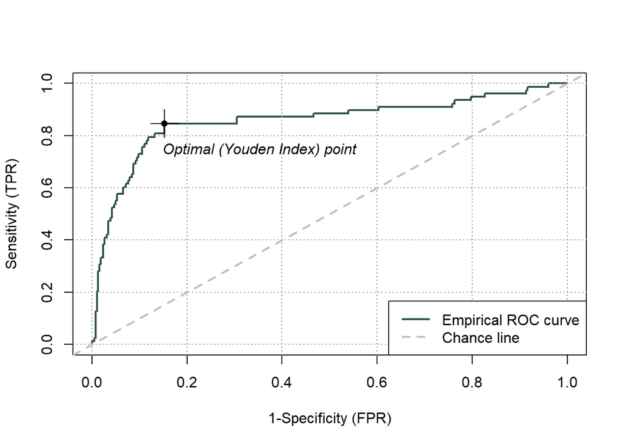

```r
# Predictions
svm_predictions <- predict(svm_model, test_data)

actual <- test_data$status_oh
roc_svm_rad = rocit(svm_predictions, actual)
plot(roc_svm_rad)
```

```r
cutoff_index <- which.max(roc_svm_rad$TPR + (1 - roc_svm_rad$FPR) - 1)
optimal_cutoff <- roc_svm_rad$Cutoff[cutoff_index]
optimal_cutoff
```

```
## [1] 0.04736292
```

```r
predicted_class_svm_rad <- ifelse(svm_predictions >= optimal_cutoff, 1, 0)

# Confusion matrix
confusionMatrix(as.factor(predicted_class_svm_rad), as.factor(test_data$status_oh))
```

```
## Confusion Matrix and Statistics
##
##           Reference
## Prediction   0   1
##          0 322  12
##          1  58  66
##
##                Accuracy : 0.8472
##                  95% CI : (0.8109, 0.8789)
##     No Information Rate : 0.8297
##     P-Value [Acc > NIR] : 0.176
##
##                   Kappa : 0.5619
##
##  Mcnemar's Test P-Value : 7.51e-08
##
##             Sensitivity : 0.8474
##             Specificity : 0.8462
##          Pos Pred Value : 0.9641
##          Neg Pred Value : 0.5323
##              Prevalence : 0.8297
##          Detection Rate : 0.7031
##    Detection Prevalence : 0.7293
##       Balanced Accuracy : 0.8468
##
##        'Positive' Class : 0
##
```

# Linear SVM metóda

```r
# Model
svm_model <- svm(status_oh ~ log(GDP) + Schooling, data = train_data, kernel = "linear")
summary(svm_model)
```

```
##
## Call:
## svm(formula = status_oh ~ log(GDP) + Schooling, data = train_data,
##     kernel = "linear")
##
##
## Parameters:
##    SVM-Type:  eps-regression
##  SVM-Kernel:  linear
##        cost:  1
##       gamma:  0.5
##     epsilon:  0.1
##
##
## Number of Support Vectors:  797
```

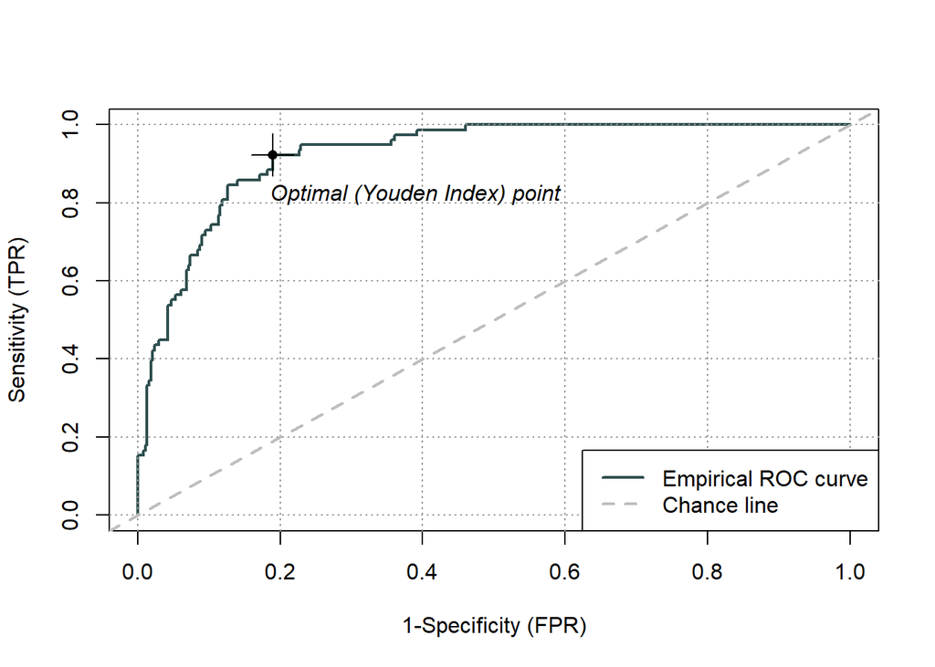

```r
# Predictions
svm_predictions <- predict(svm_model, test_data)

actual <- test_data$status_oh

roc_svm_ln = rocit(svm_predictions, actual)
plot(roc_svm_ln)
```

```r
cutoff_index <- which.max(roc_svm_ln$TPR + (1 - roc_svm_ln$FPR) - 1)
optimal_cutoff <- roc_svm_ln$Cutoff[cutoff_index]
optimal_cutoff
```

```
## [1] 0.04347608
```

```r
predicted_class_svm_ln <- ifelse(svm_predictions >= optimal_cutoff, 1, 0)

# Confusion matrix
confusionMatrix(as.factor(predicted_class_svm_ln), as.factor(test_data$status_oh))
```

```
## Confusion Matrix and Statistics
##
##           Reference
## Prediction   0   1
##          0 308   6
##          1  72  72
##
##                Accuracy : 0.8297
##                  95% CI : (0.7921, 0.863)
##     No Information Rate : 0.8297
##     P-Value [Acc > NIR] : 0.5302
##
##                   Kappa : 0.549
##
##  Mcnemar's Test P-Value : 1.842e-13
##
##             Sensitivity : 0.8105
##             Specificity : 0.9231
##          Pos Pred Value : 0.9809
##          Neg Pred Value : 0.5000
##              Prevalence : 0.8297
##          Detection Rate : 0.6725
##    Detection Prevalence : 0.6856
##       Balanced Accuracy : 0.8668
##
##        'Positive' Class : 0
##
```

```r
#predicted <- predict(svm_model,data)
#confusionMatrix(table(predicted, data$status_oh))
```

# Naive Bayes metóda

```r
# Model
nb_model <- naiveBayes(status_oh ~ log(GDP) + Schooling, data = train_data)
summary(nb_model)
```

```
##           Length Class  Mode
## apriori   2      table  numeric
## tables    2      -none- list
## levels    2      -none- character
## isnumeric 2      -none- logical
## call      4      -none- call
```

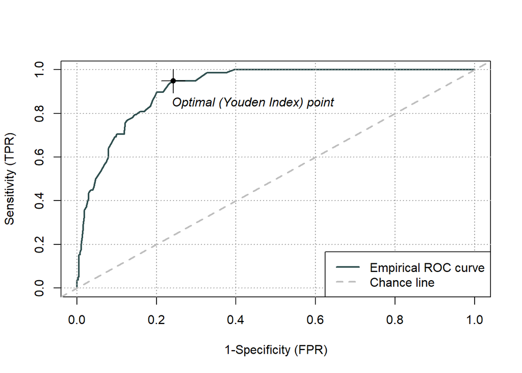

```r
# Predictions
nb_predictions <- predict(nb_model, newdata = test_data, type = "raw")

actual <- test_data$status_oh

roc_nb = rocit(nb_predictions[, 2], actual)
plot(roc_nb)
```

```r
cutoff_index <- which.max(roc_nb$TPR - roc_nb$FPR)
optimal_cutoff <- roc_nb$Cutoff[cutoff_index]

predicted_class_nb <- ifelse(nb_predictions[, 2] >= optimal_cutoff, 1, 0)

confusionMatrix(as.factor(predicted_class_nb), as.factor(test_data$status_oh))
```

```
## Confusion Matrix and Statistics
##
##           Reference
## Prediction   0   1
##          0 288   4
##          1  92  74
##
##                Accuracy : 0.7904
##                  95% CI : (0.7502, 0.8268)
##     No Information Rate : 0.8297
##     P-Value [Acc > NIR] : 0.9877
##
##                   Kappa : 0.4879
##
##  Mcnemar's Test P-Value : <2e-16
##
##             Sensitivity : 0.7579
##             Specificity : 0.9487
##          Pos Pred Value : 0.9863
##          Neg Pred Value : 0.4458
##              Prevalence : 0.8297
##          Detection Rate : 0.6288
##    Detection Prevalence : 0.6376
##       Balanced Accuracy : 0.8533
##
##        'Positive' Class : 0
##
```

## Random Forest ma problemy s chybajucimi hodnotammi v train_data, mozem ich omitnut

### gives me number of missing values in each column

```r
sapply(train_data, function(x) sum(is.na(x))) # chybajuce hodnoty v stlpcoch
```

```
##                       status_oh                         Country
##                               0                               0
##                            Year                          Status
##                               0                               0
##                 Life expectancy                 Adult Mortality
##                               0                               0
##                   infant deaths                         Alcohol
##                               0                             148
##          percentage expenditure                     Hepatitis B
##                               0                             446
##                         Measles                             BMI
##                               0                              26
##               under-five deaths                           Polio
##                               0                              13
##               Total expenditure                      Diphtheria
##                             176                              13
##                        HIV/AIDS                             GDP
##                               0                             355
##                      Population            thinness  1-19 years
##                             530                              26
##              thinness 5-9 years Income composition of resources
##                              26                             132
##                       Schooling                       Continent
##                             132                               0
```

```r
# count na data which will be omitted

nrow(na.omit(train_data))
```

```
## [1] 1310
```

```r
train_data_rf = na.omit(train_data)
```

# LDA metóda

```r
library(MASS)

# Model
lda_model <- lda(status_oh ~ log(GDP) + Schooling, data = train_data)
summary(lda_model)
```

```
##           Length Class  Mode
## prior       2    -none- numeric
## counts      2    -none- numeric
## means       4    -none- numeric
## scaling     2    -none- numeric
## lev         2    -none- character
## svd         1    -none- numeric
## N           1    -none- numeric
## call        3    -none- call
## terms       3    terms  call
## xlevels     0    -none- list
## na.action 358    omit   numeric
```

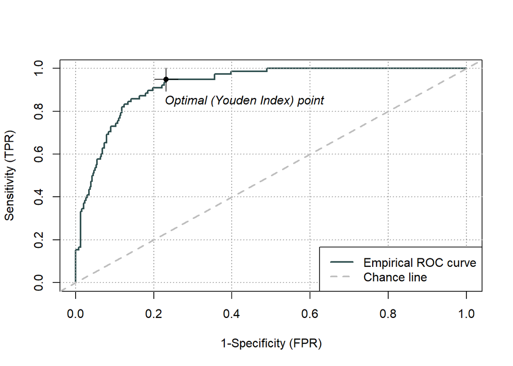

```r
# Predictions

lda_predictions <- predict(lda_model, newdata = test_data)$posterior[, "1"]

actual <- test_data$status_oh

roc_lda = rocit(lda_predictions, actual)
plot(roc_lda)
```

```r
cutoff_index <- which.max(roc_lda$TPR - roc_lda$FPR)
optimal_cutoff <- roc_lda$Cutoff[cutoff_index]

predicted_class_lda <- ifelse(lda_predictions >= optimal_cutoff, 1, 0)

confusionMatrix(as.factor(predicted_class_lda), as.factor(test_data$status_oh))
```

```
## Confusion Matrix and Statistics
##
##           Reference
## Prediction   0   1
##          0 292   4
##          1  88  74
##
##                Accuracy : 0.7991
##                  95% CI : (0.7595, 0.8349)
##     No Information Rate : 0.8297
##     P-Value [Acc > NIR] : 0.962
##
##                   Kappa : 0.5022
##
##  Mcnemar's Test P-Value : <2e-16
##
##             Sensitivity : 0.7684
##             Specificity : 0.9487
##          Pos Pred Value : 0.9865
##          Neg Pred Value : 0.4568
##              Prevalence : 0.8297
##          Detection Rate : 0.6376
##    Detection Prevalence : 0.6463
##       Balanced Accuracy : 0.8586
##
##        'Positive' Class : 0
##
```

## Model performance parameters v 1 tabuľke

```r
library(pROC)

test_data$status_oh <- as.factor(test_data$status_oh)

# Calculate performance metrics
data.frame(
  Model = c("GLM","LDA", "SVM-linear","SVM-radial", "Naive Bayes"),
  Accuracy = c(
    confusionMatrix(as.factor(predicted_class), test_data$status_oh)$overall["Accuracy"],
    confusionMatrix(as.factor(predicted_class_lda), test_data$status_oh)$overall["Accuracy"],
    confusionMatrix(as.factor(predicted_class_svm_ln), test_data$status_oh)$overall["Accuracy"],
    confusionMatrix(as.factor(predicted_class_svm_rad), test_data$status_oh)$overall["Accuracy"],
    confusionMatrix(as.factor(predicted_class_nb), test_data$status_oh)$overall["Accuracy"]
  ),
  Sensitivity = c(
    confusionMatrix(as.factor(predicted_class), test_data$status_oh)$byClass["Sensitivity"],
    confusionMatrix(as.factor(predicted_class_lda), test_data$status_oh)$byClass["Sensitivity"],
    confusionMatrix(as.factor(predicted_class_svm_ln), test_data$status_oh)$byClass["Sensitivity"],
    confusionMatrix(as.factor(predicted_class_svm_rad), test_data$status_oh)$byClass["Sensitivity"],
    confusionMatrix(as.factor(predicted_class_nb), test_data$status_oh)$byClass["Sensitivity"]
  ),
  Specificity = c(
    confusionMatrix(as.factor(predicted_class), test_data$status_oh)$byClass["Specificity"],
    confusionMatrix(as.factor(predicted_class_lda), test_data$status_oh)$byClass["Specificity"],
    confusionMatrix(as.factor(predicted_class_svm_ln), test_data$status_oh)$byClass["Specificity"],
    confusionMatrix(as.factor(predicted_class_svm_rad), test_data$status_oh)$byClass["Specificity"],
    confusionMatrix(as.factor(predicted_class_nb), test_data$status_oh)$byClass["Specificity"]
  ),
  F1_Score = c(
    confusionMatrix(as.factor(predicted_class), test_data$status_oh)$byClass["F1"],
    confusionMatrix(as.factor(predicted_class_lda), test_data$status_oh)$byClass["F1"],
    confusionMatrix(as.factor(predicted_class_svm_ln), test_data$status_oh)$byClass["F1"],
    confusionMatrix(as.factor(predicted_class_svm_rad), test_data$status_oh)$byClass["F1"],
    confusionMatrix(as.factor(predicted_class_nb), test_data$status_oh)$byClass["F1"]
  ),
  AUC_ROC = c(
    roc(test_data$status_oh, as.numeric(predicted_class))$auc,
    roc(test_data$status_oh, as.numeric(predicted_class_lda))$auc,
    roc(test_data$status_oh, as.numeric(predicted_class_svm_ln))$auc,
    roc(test_data$status_oh, as.numeric(predicted_class_svm_rad))$auc,
    roc(test_data$status_oh, as.numeric(predicted_class_nb))$auc
  )
)
```

```
##         Model  Accuracy Sensitivity Specificity  F1_Score   AUC_ROC
## 1         GLM 0.7991266   0.7684211   0.9487179 0.8639053 0.8585695
## 2         LDA 0.7991266   0.7684211   0.9487179 0.8639053 0.8585695
## 3  SVM-linear 0.8296943   0.8105263   0.9230769 0.8876081 0.8668016
## 4  SVM-radial 0.8471616   0.8473684   0.8461538 0.9019608 0.8467611
## 5 Naive Bayes 0.7903930   0.7578947   0.9487179 0.8571429 0.8533063
```

3.experiment: GPD a percentage expenditure

```r
# model
model = glm(status_oh ~ `percentage expenditure` + GDP, data = train_data)
summary(model)
```

```
##
## Call:
## glm(formula = status_oh ~ `percentage expenditure` + GDP, data = train_data)
##
## Coefficients:
##                           Estimate Std. Error t value Pr(>|t|)
## (Intercept)              9.178e-02  8.546e-03  10.740  < 2e-16 ***
## `percentage expenditure` 5.379e-05  7.913e-06   6.797 1.41e-11 ***
## GDP                      5.514e-06  1.188e-06   4.641 3.69e-06 ***
## ---
## Signif. codes:  0 '***' 0.001 '**' 0.01 '*' 0.05 '.' 0.1 ' ' 1
##
## (Dispersion parameter for gaussian family taken to be 0.1118329)
##
##     Null deviance: 294.78  on 1986  degrees of freedom
## Residual deviance: 221.88  on 1984  degrees of freedom
##   (355 observations deleted due to missingness)
## AIC: 1290.8
##
## Number of Fisher Scoring iterations: 2
```

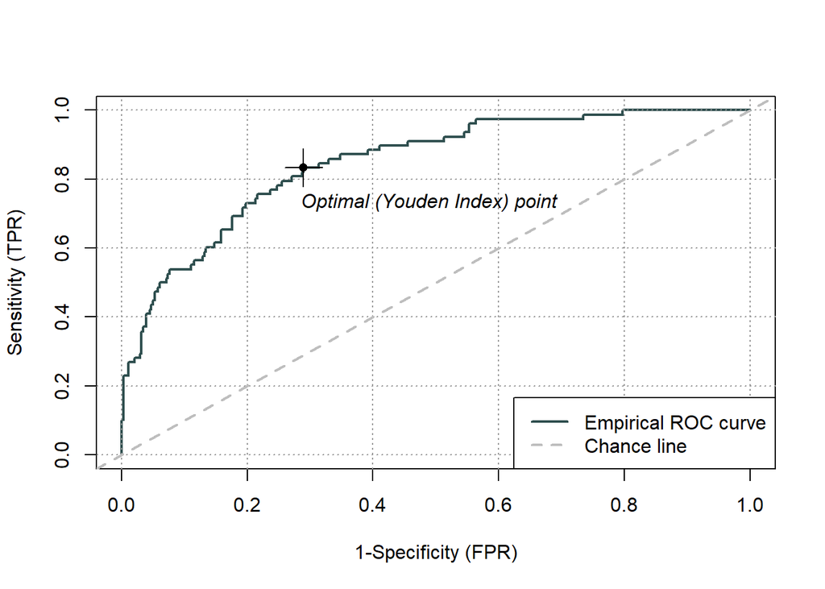

```r
predictions <- predict(model, test_data)

actual <- test_data$status_oh

# výpočet cut off hodnoty, ktorý naznačuje optimálny bod pre prahovu hodnotu, ktorá rozdeľuje predikcie na pozitívne a negatívne, čiže rozvojovú a rozvinutú krajinu.

roc = rocit(predictions, actual)
plot(roc)
```

```r
cutoff_index <- which.max(roc$TPR + (1 - roc$FPR) - 1)
optimal_cutoff <- roc$Cutoff[cutoff_index]
optimal_cutoff
```

```
## [1] 0.1272642
```

```r
predicted_class <- ifelse(predictions >= optimal_cutoff, 1, 0)

# confussion matrix
caret::confusionMatrix(as.factor(predicted_class), as.factor(actual), positive = "1")
```

```
## Confusion Matrix and Statistics
##
##           Reference
## Prediction   0   1
##          0 270  13
##          1 110  65
##
##                Accuracy : 0.7314
##                  95% CI : (0.6883, 0.7715)
##     No Information Rate : 0.8297
##     P-Value [Acc > NIR] : 1
##
##                   Kappa : 0.364
##
##  Mcnemar's Test P-Value : <2e-16
##
##             Sensitivity : 0.8333
##             Specificity : 0.7105
##          Pos Pred Value : 0.3714
##          Neg Pred Value : 0.9541
##              Prevalence : 0.1703
##          Detection Rate : 0.1419
##    Detection Prevalence : 0.3821
##       Balanced Accuracy : 0.7719
##
##        'Positive' Class : 1
##
```

[figure not shown]

```r
data %>%
  ggplot(., aes(x = `percentage expenditure`, y = status_oh)) +  # Specify X and Y variables
  geom_point(position = position_jitter(width = 0.3, height = 0.06),
             alpha = 0.05,
             shape = 1,
             size = 1.5) +
  stat_smooth(method = glm, method.args = list(family = binomial)) +
  ggtitle("Schooling vs status_oh")
```

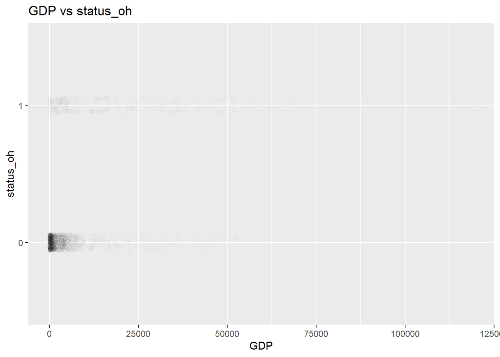

```r
data %>%
  ggplot(., aes(x = GDP, y = status_oh)) +  # Specify X and Y variables
  geom_point(position = position_jitter(width = 0.3, height = 0.06),
             alpha = 0.05,
             shape = 1,
             size = 1.5) +
  stat_smooth(method = glm, method.args = list(family = binomial)) +
  ggtitle("GDP vs status_oh")
```

# Radial SVM metóda

```r
library(e1071)

# Model
svm_model <- svm(status_oh ~ `percentage expenditure` + GDP, data = train_data, kernel = "radial")
summary(svm_model)
```

```
##
## Call:
## svm(formula = status_oh ~ `percentage expenditure` + GDP, data = train_data,
##     kernel = "radial")
##
##
## Parameters:
##    SVM-Type:  eps-regression
##  SVM-Kernel:  radial
##        cost:  1
##       gamma:  0.5
##     epsilon:  0.1
##
##
## Number of Support Vectors:  580
```

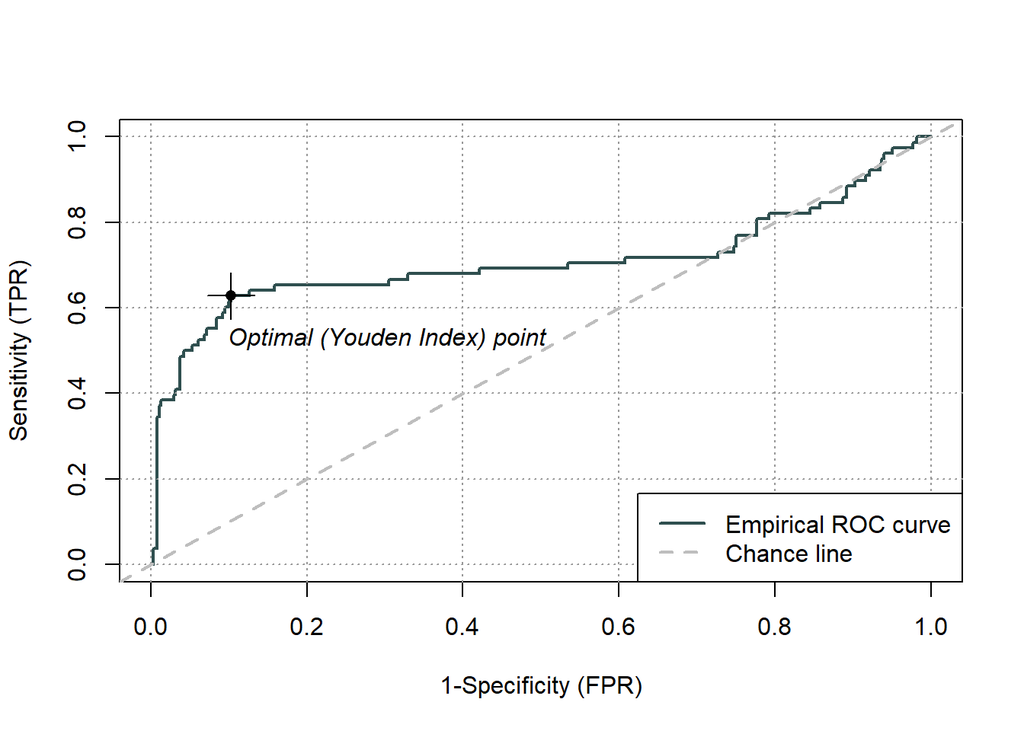

```r
# Predictions
svm_predictions <- predict(svm_model, test_data)

actual <- test_data$status_oh
roc_svm_rad = rocit(svm_predictions, actual)
plot(roc_svm_rad)
```

```r
cutoff_index <- which.max(roc_svm_rad$TPR + (1 - roc_svm_rad$FPR) - 1)
optimal_cutoff <- roc_svm_rad$Cutoff[cutoff_index]
optimal_cutoff
```

```
## [1] 0.04010034
```

```r
predicted_class_svm_rad <- ifelse(svm_predictions >= optimal_cutoff, 1, 0)

# Confusion matrix
confusionMatrix(as.factor(predicted_class_svm_rad), as.factor(test_data$status_oh))
```

```
## Confusion Matrix and Statistics
##
##           Reference
## Prediction   0   1
##          0 341  29
##          1  39  49
##
##                Accuracy : 0.8515
##                  95% CI : (0.8156, 0.8828)
##     No Information Rate : 0.8297
##     P-Value [Acc > NIR] : 0.1176
##
##                   Kappa : 0.5001
##
##  Mcnemar's Test P-Value : 0.2751
##
##             Sensitivity : 0.8974
##             Specificity : 0.6282
##          Pos Pred Value : 0.9216
##          Neg Pred Value : 0.5568
##              Prevalence : 0.8297
##          Detection Rate : 0.7445
##    Detection Prevalence : 0.8079
##       Balanced Accuracy : 0.7628
##
##        'Positive' Class : 0
##
```

# Linear SVM metóda

```r
# Model
svm_model <- svm(status_oh ~ `percentage expenditure` + GDP, data = train_data, kernel = "linear")
summary(svm_model)
```

```
##
## Call:
## svm(formula = status_oh ~ `percentage expenditure` + GDP, data = train_data,
##     kernel = "linear")
##
##
## Parameters:
##    SVM-Type:  eps-regression
##  SVM-Kernel:  linear
##        cost:  1
##       gamma:  0.5
##     epsilon:  0.1
##
##
## Number of Support Vectors:  672
```

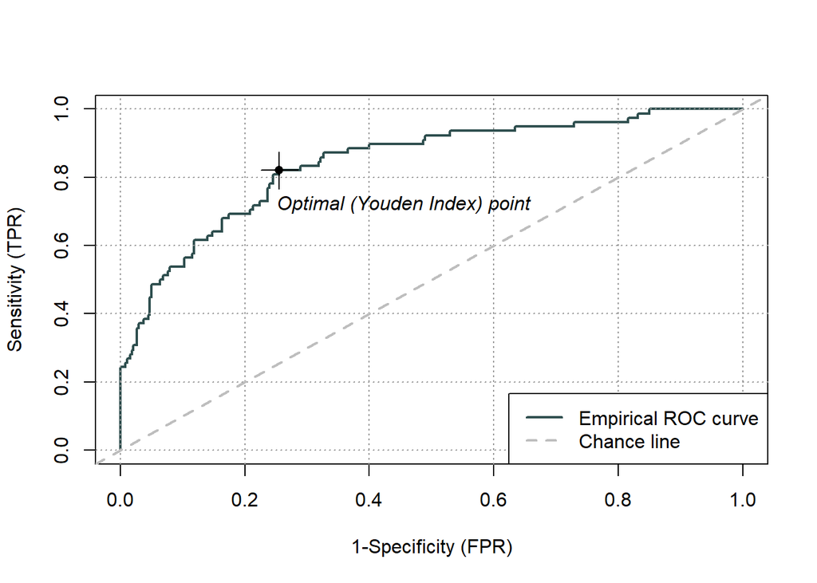

```r
# Predictions
svm_predictions <- predict(svm_model, test_data)

actual <- test_data$status_oh

roc_svm_ln = rocit(svm_predictions, actual)
plot(roc_svm_ln)
```

```r
cutoff_index <- which.max(roc_svm_ln$TPR + (1 - roc_svm_ln$FPR) - 1)
optimal_cutoff <- roc_svm_ln$Cutoff[cutoff_index]
optimal_cutoff
```

```
## [1] 0.02560455
```

```r
predicted_class_svm_ln <- ifelse(svm_predictions >= optimal_cutoff, 1, 0)

# Confusion matrix
confusionMatrix(as.factor(predicted_class_svm_ln), as.factor(test_data$status_oh))
```

```
## Confusion Matrix and Statistics
##
##           Reference
## Prediction   0   1
##          0 283  14
##          1  97  64
##
##                Accuracy : 0.7576
##                  95% CI : (0.7157, 0.7962)
##     No Information Rate : 0.8297
##     P-Value [Acc > NIR] : 1
##
##                   Kappa : 0.3973
##
##  Mcnemar's Test P-Value : 7.077e-15
##
##             Sensitivity : 0.7447
##             Specificity : 0.8205
##          Pos Pred Value : 0.9529
##          Neg Pred Value : 0.3975
##              Prevalence : 0.8297
##          Detection Rate : 0.6179
##    Detection Prevalence : 0.6485
##       Balanced Accuracy : 0.7826
##
##        'Positive' Class : 0
##
```

```r
#predicted <- predict(svm_model,data)
#confusionMatrix(table(predicted, data$status_oh))
```

# Naive Bayes metóda

```r
# Model
nb_model <- naiveBayes(status_oh ~ `percentage expenditure` + GDP, data = train_data)
summary(nb_model)
```

```
##           Length Class  Mode
## apriori   2      table  numeric
## tables    2      -none- list
## levels    2      -none- character
## isnumeric 2      -none- logical
## call      4      -none- call
```

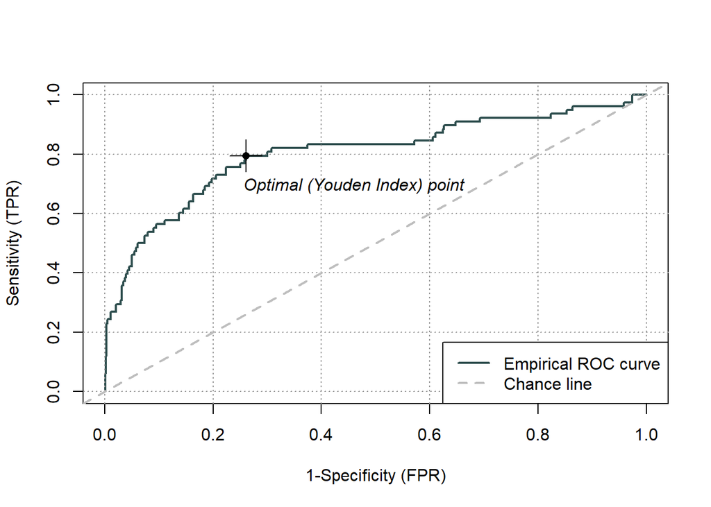

```r
# Predictions
nb_predictions <- predict(nb_model, newdata = test_data, type = "raw")

actual <- test_data$status_oh

roc_nb = rocit(nb_predictions[, 2], actual)
plot(roc_nb)
```

```r
cutoff_index <- which.max(roc_nb$TPR - roc_nb$FPR)
optimal_cutoff <- roc_nb$Cutoff[cutoff_index]

predicted_class_nb <- ifelse(nb_predictions[, 2] >= optimal_cutoff, 1, 0)

confusionMatrix(as.factor(predicted_class_nb), as.factor(test_data$status_oh))
```

```
## Confusion Matrix and Statistics
##
##           Reference
## Prediction   0   1
##          0 281  16
##          1  99  62
##
##                Accuracy : 0.7489
##                  95% CI : (0.7066, 0.788)
##     No Information Rate : 0.8297
##     P-Value [Acc > NIR] : 1
##
##                   Kappa : 0.3755
##
##  Mcnemar's Test P-Value : 2.065e-14
##
##             Sensitivity : 0.7395
##             Specificity : 0.7949
##          Pos Pred Value : 0.9461
##          Neg Pred Value : 0.3851
##              Prevalence : 0.8297
##          Detection Rate : 0.6135
##    Detection Prevalence : 0.6485
##       Balanced Accuracy : 0.7672
##
##        'Positive' Class : 0
##
```

# LDA metóda

```r
library(MASS)

# Model
lda_model <- lda(status_oh ~ `percentage expenditure` + GDP, data = train_data)
summary(lda_model)
```

```
##           Length Class  Mode
## prior       2    -none- numeric
## counts      2    -none- numeric
## means       4    -none- numeric
## scaling     2    -none- numeric
## lev         2    -none- character
## svd         1    -none- numeric
## N           1    -none- numeric
## call        3    -none- call
## terms       3    terms  call
## xlevels     0    -none- list
## na.action 355    omit   numeric
```

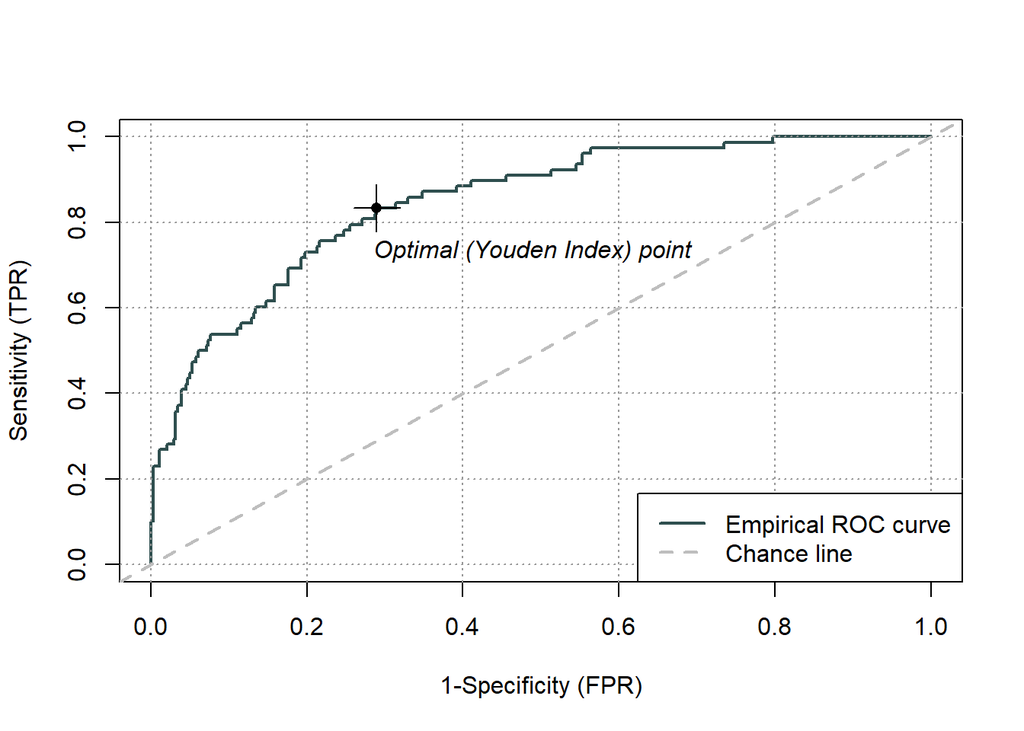

```r
# Predictions

lda_predictions <- predict(lda_model, newdata = test_data)$posterior[, "1"]

actual <- test_data$status_oh

roc_lda = rocit(lda_predictions, actual)
plot(roc_lda)
```

```r
cutoff_index <- which.max(roc_lda$TPR - roc_lda$FPR)
optimal_cutoff <- roc_lda$Cutoff[cutoff_index]

predicted_class_lda <- ifelse(lda_predictions >= optimal_cutoff, 1, 0)

confusionMatrix(as.factor(predicted_class_lda), as.factor(test_data$status_oh))
```

```
## Confusion Matrix and Statistics
##
##           Reference
## Prediction   0   1
##          0 270  13
##          1 110  65
##
##                Accuracy : 0.7314
##                  95% CI : (0.6883, 0.7715)
##     No Information Rate : 0.8297
##     P-Value [Acc > NIR] : 1
##
##                   Kappa : 0.364
##
##  Mcnemar's Test P-Value : <2e-16
##
##             Sensitivity : 0.7105
##             Specificity : 0.8333
##          Pos Pred Value : 0.9541
##          Neg Pred Value : 0.3714
##              Prevalence : 0.8297
##          Detection Rate : 0.5895
##    Detection Prevalence : 0.6179
##       Balanced Accuracy : 0.7719
##
##        'Positive' Class : 0
##
```

## Model performance parameters v 1 tabuľke

```r
library(pROC)

test_data$status_oh <- as.factor(test_data$status_oh)

# Calculate performance metrics
data.frame(
  Model = c("GLM","LDA", "SVM-linear","SVM-radial", "Naive Bayes"),
  Accuracy = c(
    confusionMatrix(as.factor(predicted_class), test_data$status_oh)$overall["Accuracy"],
    confusionMatrix(as.factor(predicted_class_lda), test_data$status_oh)$overall["Accuracy"],
    confusionMatrix(as.factor(predicted_class_svm_ln), test_data$status_oh)$overall["Accuracy"],
    confusionMatrix(as.factor(predicted_class_svm_rad), test_data$status_oh)$overall["Accuracy"],
    confusionMatrix(as.factor(predicted_class_nb), test_data$status_oh)$overall["Accuracy"]
  ),
  Sensitivity = c(
    confusionMatrix(as.factor(predicted_class), test_data$status_oh)$byClass["Sensitivity"],
    confusionMatrix(as.factor(predicted_class_lda), test_data$status_oh)$byClass["Sensitivity"],
    confusionMatrix(as.factor(predicted_class_svm_ln), test_data$status_oh)$byClass["Sensitivity"],
    confusionMatrix(as.factor(predicted_class_svm_rad), test_data$status_oh)$byClass["Sensitivity"],
    confusionMatrix(as.factor(predicted_class_nb), test_data$status_oh)$byClass["Sensitivity"]
  ),
  Specificity = c(
    confusionMatrix(as.factor(predicted_class), test_data$status_oh)$byClass["Specificity"],
    confusionMatrix(as.factor(predicted_class_lda), test_data$status_oh)$byClass["Specificity"],
    confusionMatrix(as.factor(predicted_class_svm_ln), test_data$status_oh)$byClass["Specificity"],
    confusionMatrix(as.factor(predicted_class_svm_rad), test_data$status_oh)$byClass["Specificity"],
    confusionMatrix(as.factor(predicted_class_nb), test_data$status_oh)$byClass["Specificity"]
  ),
  F1_Score = c(
    confusionMatrix(as.factor(predicted_class), test_data$status_oh)$byClass["F1"],
    confusionMatrix(as.factor(predicted_class_lda), test_data$status_oh)$byClass["F1"],
    confusionMatrix(as.factor(predicted_class_svm_ln), test_data$status_oh)$byClass["F1"],
    confusionMatrix(as.factor(predicted_class_svm_rad), test_data$status_oh)$byClass["F1"],
    confusionMatrix(as.factor(predicted_class_nb), test_data$status_oh)$byClass["F1"]
  ),
  AUC_ROC = c(
    roc(test_data$status_oh, as.numeric(predicted_class))$auc,
    roc(test_data$status_oh, as.numeric(predicted_class_lda))$auc,
    roc(test_data$status_oh, as.numeric(predicted_class_svm_ln))$auc,
    roc(test_data$status_oh, as.numeric(predicted_class_svm_rad))$auc,
    roc(test_data$status_oh, as.numeric(predicted_class_nb))$auc
  )
)
```

```
##         Model  Accuracy Sensitivity Specificity  F1_Score   AUC_ROC
## 1         GLM 0.7314410   0.7105263   0.8333333 0.8144796 0.7719298
## 2         LDA 0.7314410   0.7105263   0.8333333 0.8144796 0.7719298
## 3  SVM-linear 0.7576419   0.7447368   0.8205128 0.8360414 0.7826248
## 4  SVM-radial 0.8515284   0.8973684   0.6282051 0.9093333 0.7627868
## 5 Naive Bayes 0.7489083   0.7394737   0.7948718 0.8301329 0.7671727
```

```r
#set.seed(123)
# one-hot encoding column status
#data$status_oh <- as.factor(data$status_oh)

#train_control <- trainControl(method = "cv",
 #                             number = 10)

#remove NA values
#data <- na.omit(data)

#model
#model <- train(status_oh ~ `percentage expenditure` + GDP, data = data,
  #             trControl = train_control,
    #           method = "nb")

#print(model)
```